# for_medium

### PRACTICE END TO END MACHINE LEARNING (ECONOMIC OUTLOOK)

The core reason behind this piece of work is to put a thorough exploratory data analysis and key visualizations that drive critical insights in analytics and statistics, in details in one notebook. Please note that the emphasis is on the journey of the analysis much more than the level of accuracy. Before you begin with any data science project or any project in general, you must know why it is being built.

#### For a data science project, you might be asked to do one or more of these tasks:

```
 -predict something
 -Explore the dataset and find reasons for something
```

In this case we will be building this model to predict **inflation for Nigeria using multiple linear regression**. From the name Data Science we see that Data is the most important cog of your data science project wheel, In this case we will be working with secondary data attached bellow.

#### Now we dive fully into our analysis by first importing all the libraries needed for the analysis

```python
#Importing all the necessary libraries for the analysis

import pandas as pd
import numpy as np
import matplotlib.pyplot as plt
import seaborn as sns
from sklearn.model_selection import train_test_split
from sklearn.linear_model import LinearRegression
from sklearn import metrics
%matplotlib inline
```

Pandas provides tools for reading and writing data into data structures and files and also provides powerful aggregation functions to manipulate data.

NumPy overcomes slower executions with the use of multi dimensional array objects. It has inbuilt functions for manipulating arrays.

Matplotlib.pyplot; makes matplotlib work like MATLAB, Matplotlib is a plotting library.

seaborn is used for making statistical graphics. The central part of seaborn is visualization which helps in exploring and understanding data.

train_test_split is used to evaluate the performance of a machine learnin algorithm, in this case Regression problem.

LinearRegression is used to solve the regression problem by predicting the target variable using the line of best fit(the best relationship between the independent and dependent variable)

metrics is used to analyze the performance of the model

%matplotlib inline makes your plot outputs appear and be stored within the notebook

#### We read the data (excel file) saved in my PC into the notebook

```python
#pd.read_excel is a pandas method
mydata = pd.read_excel(r'C:\Users\User\Desktop\PROGRAMMING ITEMS\african.xlsx')
```

#### We check the shape of our data, that is the number of rows and columns.

```python
mydata.shape
```

```
(1732, 48)
```

```python
mydata.head(2) #.head() is a pandas function
```

|  | Country and Regions | Country and Regions Name | Country and Regions - RegionId | Indicators | Indicators Name | Scale | Units | 1980 | 1981 | 1982 | ... | 2011 | 2012 | 2013 | 2014 | 2015 | 2016 | 2017 | 2018 | 2019 | 2020 |
| --- | --- | --- | --- | --- | --- | --- | --- | --- | --- | --- | --- | --- | --- | --- | --- | --- | --- | --- | --- | --- | --- |
| 0 | DZA | Algeria | DZ | NY.GDP.MKTP.KD.ZG | Real GDP growth (annual %) | units | percentage | NaN | 3.000005 | 6.400001 | ... | 2.900000 | 3.400000 | 2.800000 | 3.800000 | 3.700000 | 3.200000 | 1.40000 | 2.544479 | 2.689753 | 1.867171 |
| 1 | DZA | Algeria | DZ | NY.GDP.PCAP.KD.ZG | Real per Capita GDP Growth Rate (annual %) | units | percentage | NaN | -0.129448 | 3.131644 | ... | 0.938334 | 1.345839 | 0.728063 | 1.743944 | 1.727994 | 1.333212 | -0.34756 | 0.860358 | 1.075350 | 0.329201 |

2 rows × 48 columns

#### lets see a larger picture of the dataset by calling the dataset by its name which shows us all rows and columns

```python
mydata
```

|  | Country and Regions | Country and Regions Name | Country and Regions - RegionId | Indicators | Indicators Name | Scale | Units | 1980 | 1981 | 1982 | ... | 2011 | 2012 | 2013 | 2014 | 2015 | 2016 | 2017 | 2018 | 2019 | 2020 |
| --- | --- | --- | --- | --- | --- | --- | --- | --- | --- | --- | --- | --- | --- | --- | --- | --- | --- | --- | --- | --- | --- |
| 0 | DZA | Algeria | DZ | NY.GDP.MKTP.KD.ZG | Real GDP growth (annual %) | units | percentage | NaN | 3.000005 | 6.400001 | ... | 2.900000 | 3.400000 | 2.800000 | 3.800000 | 3.700000 | 3.200000 | 1.400000 | 2.544479 | 2.689753 | 1.867171 |
| 1 | DZA | Algeria | DZ | NY.GDP.PCAP.KD.ZG | Real per Capita GDP Growth Rate (annual %) | units | percentage | NaN | -0.129448 | 3.131644 | ... | 0.938334 | 1.345839 | 0.728063 | 1.743944 | 1.727994 | 1.333212 | -0.347560 | 0.860358 | 1.075350 | 0.329201 |
| 2 | DZA | Algeria | DZ | NY.GDP.MKTP.KD | Gross domestic product, (constant prices US$) | millions | U.S. dollars | 34512.329728 | 35547.701326 | 37822.754445 | ... | 82306.010060 | 85104.414402 | 87487.338005 | 90811.856849 | 94171.895553 | 97185.396210 | 98545.991757 | 101053.473884 | 103771.562863 | 105709.155649 |
| 3 | DZA | Algeria | DZ | NY.GDP.MKTP.CD | Gross domestic product, current prices (curren... | millions | U.S. dollars | 42345.827687 | 44371.759808 | 44779.983360 | ... | 200019.103013 | 209059.083118 | 209755.003251 | 213809.978239 | 165967.810237 | 160132.094556 | 167552.812075 | 181354.494429 | 187422.917508 | 193705.489155 |
| 4 | DZA | Algeria | DZ | NE.CON.TETC.CD | Final consumption expenditure (current US$) | millions | U.S. dollars | 24112.626875 | 26305.606595 | 27485.578776 | ... | 103696.510707 | 109684.113910 | 112849.091074 | 120060.948870 | 103851.459393 | 102155.457084 | 104656.071799 | 110184.109060 | 113666.188267 | 117069.974688 |
| ... | ... | ... | ... | ... | ... | ... | ... | ... | ... | ... | ... | ... | ... | ... | ... | ... | ... | ... | ... | ... | ... |
| 1727 | SSA | Sub-Saharan Africa | NaN | BG.WEO.ADB.CAB.GDP.ZS | Current account balance (As % of GDP) | units | Percentage of GDP | -0.339211 | -6.846689 | -6.453001 | ... | -0.801623 | -2.048641 | -2.671717 | -3.968057 | -6.056041 | -3.783243 | -2.223782 | -2.172056 | -2.119139 | -2.285076 |
| 1728 | SSA | Sub-Saharan Africa | NaN | FP.CPI.TOTL.ZG | Inflation, consumer prices (annual %) | units | percentage | NaN | NaN | NaN | ... | 9.738610 | 10.298313 | 7.694117 | 7.459005 | 7.283639 | 11.263958 | 11.716643 | 9.760410 | 9.120216 | 8.479765 |
| 1729 | NaN | NaN | NaN | NaN | NaN | NaN | NaN | NaN | NaN | NaN | ... | NaN | NaN | NaN | NaN | NaN | NaN | NaN | NaN | NaN | NaN |
| 1730 | Source: | African Development Bank | NaN | NaN | NaN | NaN | NaN | NaN | NaN | NaN | ... | NaN | NaN | NaN | NaN | NaN | NaN | NaN | NaN | NaN | NaN |
| 1731 | Download URL: | http://dataportal.opendataforafrica.org/mhuicc... | NaN | NaN | NaN | NaN | NaN | NaN | NaN | NaN | ... | NaN | NaN | NaN | NaN | NaN | NaN | NaN | NaN | NaN | NaN |

1732 rows × 48 columns

### Data cleaning

From observation the dataset has different countries (the second column), But since we are only interested in predicting inflation for Nigeria, it implies rows for other countries are not useful in the analysis, this process of removing irrelevant information and making the data ready for proper analysis is called **Data cleaning**

```python
#we want to consider only the rows containing nigeria

mydata1 = mydata[mydata['Country and Regions Name'] == 'Nigeria']
mydata1.head()
```

|  | Country and Regions | Country and Regions Name | Country and Regions - RegionId | Indicators | Indicators Name | Scale | Units | 1980 | 1981 | 1982 | ... | 2011 | 2012 | 2013 | 2014 | 2015 | 2016 | 2017 | 2018 | 2019 | 2020 |
| --- | --- | --- | --- | --- | --- | --- | --- | --- | --- | --- | --- | --- | --- | --- | --- | --- | --- | --- | --- | --- | --- |
| 1102 | NGA | Nigeria | NG | NY.GDP.MKTP.KD.ZG | Real GDP growth (annual %) | units | percentage | NaN | 20.838228 | -1.053188 | ... | 4.887387 | 4.279277 | 5.394416 | 6.309719 | 2.652693 | -1.583065 | 0.824000 | 1.942723 | 2.340113 | 2.445497 |
| 1103 | NGA | Nigeria | NG | NY.GDP.PCAP.KD.ZG | Real per Capita GDP Growth Rate (annual %) | units | percentage | NaN | 17.601531 | -3.595229 | ... | 2.119094 | 1.524086 | 2.614626 | 3.519624 | -0.022235 | -4.127177 | -1.762366 | -0.653750 | -0.250534 | -0.133762 |
| 1104 | NGA | Nigeria | NG | NY.GDP.MKTP.KD | Gross domestic product, (constant prices US$) | millions | U.S. dollars | 30445.470817 | 36789.767429 | 36402.301867 | ... | 117250.679507 | 122268.161173 | 128863.814799 | 136994.758970 | 140628.809748 | 138402.563588 | 139543.000712 | 142253.934021 | 145582.836389 | 149143.060242 |
| 1105 | NGA | Nigeria | NG | NY.GDP.MKTP.CD | Gross domestic product, current prices (curren... | millions | U.S. dollars | 60592.526142 | 62312.448573 | 53934.018069 | ... | 414095.238505 | 460951.712209 | 513258.046204 | 554863.289257 | 494583.095076 | 404649.570538 | 375745.475265 | 409182.443364 | 458464.952758 | 512956.808745 |
| 1106 | NGA | Nigeria | NG | NE.CON.TETC.CD | Final consumption expenditure (current US$) | millions | U.S. dollars | 48410.741711 | 53218.503130 | 45332.194900 | ... | 306109.609667 | 306970.569907 | 412205.424499 | 444635.629972 | 417971.820183 | 351719.602385 | 317618.203141 | 333461.443419 | 379896.842103 | 429956.738272 |

5 rows × 48 columns

#### Now we want to transpose the data, such that the present colon which contain years becomes the new rows

```python
#transposing data
mydata2 = mydata1.transpose()
#check to see the present index
mydata2.index
```

```
Index(['Country and Regions', 'Country and Regions Name',
       'Country and Regions - RegionId', 'Indicators', 'Indicators Name',
       'Scale', 'Units', '1980', '1981', '1982', '1983', '1984', '1985',
       '1986', '1987', '1988', '1989', '1990', '1991', '1992', '1993', '1994',
       '1995', '1996', '1997', '1998', '1999', '2000', '2001', '2002', '2003',
       '2004', '2005', '2006', '2007', '2008', '2009', '2010', '2011', '2012',
       '2013', '2014', '2015', '2016', '2017', '2018', '2019', '2020'],
      dtype='object')
```

#### Lets have a clear view of our transposed data now.

```python
mydata2
```

|  | 1102 | 1103 | 1104 | 1105 | 1106 | 1107 | 1108 | 1109 | 1110 | 1111 | ... | 1121 | 1122 | 1123 | 1124 | 1125 | 1126 | 1127 | 1128 | 1129 | 1130 |
| --- | --- | --- | --- | --- | --- | --- | --- | --- | --- | --- | --- | --- | --- | --- | --- | --- | --- | --- | --- | --- | --- |
| Country and Regions | NGA | NGA | NGA | NGA | NGA | NGA | NGA | NGA | NGA | NGA | ... | NGA | NGA | NGA | NGA | NGA | NGA | NGA | NGA | NGA | NGA |
| Country and Regions Name | Nigeria | Nigeria | Nigeria | Nigeria | Nigeria | Nigeria | Nigeria | Nigeria | Nigeria | Nigeria | ... | Nigeria | Nigeria | Nigeria | Nigeria | Nigeria | Nigeria | Nigeria | Nigeria | Nigeria | Nigeria |
| Country and Regions - RegionId | NG | NG | NG | NG | NG | NG | NG | NG | NG | NG | ... | NG | NG | NG | NG | NG | NG | NG | NG | NG | NG |
| Indicators | NY.GDP.MKTP.KD.ZG | NY.GDP.PCAP.KD.ZG | NY.GDP.MKTP.KD | NY.GDP.MKTP.CD | NE.CON.TETC.CD | NE.CON.GOVT.CD | NE.CON.PETC.CD | NE.GDI.TOTL.CD | NE.GDI.PVTE.CD | NE.GDI.PUB.CD | ... | NE.IMP.GNFS.ZS | GC.BAL.CASH.GD.CD | GC.REV.TOTL.GD.CD | GC.XPN.TOTL.GD.CD | GC.BAL.CASH.GD.ZS | GC.REV.TOTL.GD.ZS | GC.XPN.TOTL.GD.ZS | BG.CAB.CD | BG.WEO.ADB.CAB.GDP.ZS | FP.CPI.TOTL.ZG |
| Indicators Name | Real GDP growth (annual %) | Real per Capita GDP Growth Rate (annual %) | Gross domestic product, (constant prices US$) | Gross domestic product, current prices (curren... | Final consumption expenditure (current US$) | General government final consumption expenditu... | Household final consumption expenditure (curre... | Gross capital formation (current US$) | Gross capital formation, Private sector (curr... | Gross capital formation, Public sector (curre... | ... | Imports of goods and services (% of GDP) | Central government, Fiscal Balance (Current US $) | Central government, total revenue and grants ... | Central government, total expenditure and net ... | Central government, Fiscal Balance (% of GDP) | Central government, total revenue and grants ... | Central government, total expenditure and net ... | Current account balance (Net, BoP, cur. US$) | Current account balance (As % of GDP) | Inflation, consumer prices (annual %) |
| Scale | units | units | millions | millions | millions | millions | millions | millions | millions | millions | ... | units | millions | millions | millions | units | units | units | millions | units | units |
| Units | percentage | percentage | U.S. dollars | U.S. dollars | U.S. dollars | U.S. dollars | U.S. dollars | U.S. dollars | U.S. dollars | U.S. dollars | ... | Percentage of GDP | U.S. dollars | U.S. dollars | U.S. dollars | Percentage of GDP | Percentage of GDP | Percentage of GDP | U.S. dollars | Percentage of GDP | percentage |
| 1980 | NaN | NaN | 30445.5 | 60592.5 | 48410.7 | 6427.03 | 41983.7 | 12000.3 | 6660.27 | 5339.99 | ... | 24.0153 | -2230.34 | 12580.6 | 14810.9 | -3.68088 | 20.7626 | 24.4435 | 5361.54 | 8.84852 | NaN |
| 1981 | 20.8382 | 17.6015 | 36789.8 | 62312.4 | 53218.5 | 7972.78 | 45245.7 | 11556.3 | 5977.71 | 5578.54 | ... | 28.0388 | -7450.16 | 7956.97 | 15407.1 | -11.9561 | 12.7695 | 24.7256 | -6144.75 | -9.86119 | 20.7765 |
| 1982 | -1.05319 | -3.59523 | 36402.3 | 53934 | 45332.2 | 6850.94 | 38481.3 | 10487.5 | 5290.28 | 5197.21 | ... | 23.0828 | -8496.94 | 6802.09 | 15299 | -15.7543 | 12.6119 | 28.3662 | -7186.48 | -13.3246 | 7.71226 |
| 1983 | -5.05045 | -7.42755 | 34563.8 | 36507.7 | 30828.2 | 4716.89 | 26111.4 | 6600.11 | 3593.35 | 3006.76 | ... | 17.3317 | -4718.61 | 3864.24 | 8582.86 | -12.925 | 10.5847 | 23.5097 | -5133.26 | -14.0608 | 23.2012 |
| 1984 | -2.02154 | -4.46862 | 33865.1 | 26475.8 | 27598.7 | 2850.23 | 24748.5 | 5732.12 | 5047.99 | 684.132 | ... | 40.9884 | -1744.25 | 2478.61 | 4222.87 | -6.5881 | 9.36182 | 15.9499 | -1050.97 | -3.96957 | 39.6011 |
| 1985 | 8.32283 | 5.58207 | 36683.6 | 25966 | 26658.2 | 2052.82 | 24605.4 | 5735.01 | 5306.67 | 428.34 | ... | 40.1641 | -426.799 | 3403.77 | 3830.57 | -1.64369 | 13.1086 | 14.7522 | -200.447 | -0.771959 | 5.53064 |
| 1986 | -8.75418 | -11.0988 | 33472.3 | 20562.8 | 19299.7 | 2102.39 | 17197.3 | 5077.22 | 5747.22 | -669.995 | ... | 41.5118 | 780.013 | 2791.54 | 2011.53 | 3.79332 | 13.5757 | 9.78234 | -3854.59 | -18.7454 | 5.35681 |
| 1987 | -10.7517 | -13.0645 | 29873.4 | 21911.8 | 17130.6 | 3288.3 | 13842.3 | 4302.94 | 3992.25 | 310.689 | ... | 30.5269 | -1177.56 | 2495.87 | 3673.42 | -5.37407 | 11.3905 | 16.7646 | -1305.12 | -5.95627 | 10.1873 |
| 1988 | 7.54252 | 4.75004 | 32126.7 | 24311.3 | 20886.2 | 3399.83 | 17486.3 | 4317.29 | 4095.88 | 221.411 | ... | 27.2766 | -1142.83 | 2641.69 | 3784.52 | -4.7008 | 10.8661 | 15.5669 | -1950.58 | -8.02336 | 34.5162 |
| 1989 | 6.46719 | 3.72184 | 34204.3 | 23487.1 | 18217.3 | 3302.18 | 14915.1 | 4845.72 | 4693.99 | 151.729 | ... | 31.0819 | -634.553 | 3175.48 | 3810.04 | -2.7017 | 13.5201 | 16.2218 | 649.443 | 2.7651 | 50.4521 |
| 1990 | 12.766 | 9.89491 | 38570.9 | 31480 | 19950.2 | 3466.53 | 16483.7 | 6911.89 | 5803.86 | 1108.03 | ... | 29.1132 | 935.729 | 6039.02 | 5103.29 | 2.97246 | 19.1837 | 16.2113 | 2398.48 | 7.61908 | 7.35704 |
| 1991 | -0.617849 | -3.1158 | 38332.6 | 28336.9 | 21562.5 | 3154.13 | 18408.3 | 6501.1 | 5628.02 | 873.074 | ... | 38.0864 | 197.703 | 4769.45 | 4571.74 | 0.697689 | 16.8312 | 16.1335 | -336.091 | -1.18606 | 24.103 |
| 1992 | 0.433726 | -2.0668 | 38498.8 | 25521.8 | 21227.4 | 2322.01 | 18905.4 | 6053.31 | 5735.67 | 317.647 | ... | 45.1993 | 531.876 | 4324.62 | 3792.74 | 2.08401 | 16.9448 | 14.8608 | -1108.31 | -4.34259 | 44.8048 |
| 1993 | 2.09038 | -0.4332 | 39303.6 | 15789.7 | 16504.6 | 1951.81 | 14552.8 | 4816.83 | 5255.6 | -438.773 | ... | 67.8895 | -1076.87 | 2325.76 | 3402.62 | -6.82007 | 14.7296 | 21.5496 | -1900.64 | -12.0372 | 57.169 |
| 1994 | 0.909761 | -1.57482 | 39661.2 | 18086.4 | 18213.7 | 2363.96 | 15849.7 | 4505.19 | 4442.02 | 63.1774 | ... | 53.3342 | -1144.58 | 1971.57 | 3116.15 | -6.3284 | 10.9008 | 17.2292 | -1468.49 | -8.11931 | 57.03 |
| 1995 | -0.307466 | -2.75861 | 39539.2 | 36945.5 | 22818.4 | 2303.57 | 20514.9 | 4153.5 | 2508.42 | 1645.08 | ... | 31.944 | 1262.07 | 5843.21 | 4581.14 | 3.41604 | 15.8158 | 12.3997 | -1570.81 | -4.2517 | 72.8519 |
| 1996 | 4.99371 | 2.41332 | 41513.7 | 46019.8 | 26179.4 | 2360.43 | 23819 | 5501.01 | 3751.56 | 1749.44 | ... | 27.5574 | 1185.52 | 6024.26 | 4838.74 | 2.57611 | 13.0906 | 10.5145 | 1908 | 4.14605 | 29.2615 |
| 1997 | 2.80226 | 0.275909 | 42677 | 35386.2 | 26486 | 2527.95 | 23958 | 6056.7 | 4154.88 | 1901.82 | ... | 39.3319 | -357.804 | 4495.98 | 4853.79 | -1.01114 | 12.7055 | 13.7166 | 1693.29 | 4.78517 | 8.53562 |
| 1998 | 2.71564 | 0.188874 | 43836 | 32748.9 | 25931.3 | 3939.81 | 21991.5 | 8643.77 | 4943.29 | 3700.48 | ... | 38.3126 | -2976.74 | 3325.58 | 6302.33 | -9.0896 | 10.1548 | 19.2444 | -3027.18 | -9.24359 | 9.98882 |
| 1999 | 0.474238 | -2.00238 | 44043.9 | 35870.8 | 27928.3 | 4943.32 | 22985 | 10329.7 | 7798.14 | 2531.52 | ... | 41.1454 | -1853.7 | 7255.35 | 9109.05 | -5.16771 | 20.2263 | 25.394 | -1416.54 | -3.949 | 6.61755 |
| 2000 | 5.31809 | 2.71429 | 46386.1 | 46386.1 | 26896.1 | 9623.37 | 17272.7 | 9449.97 | 5044.89 | 4405.08 | ... | 32.1518 | 2757.08 | 19537.9 | 16780.8 | 5.94376 | 42.1202 | 36.1764 | 5786.34 | 12.4743 | 6.94444 |
| 2001 | 8.16431 | 5.48189 | 50173.3 | 44138.1 | 28651.1 | 12811.5 | 15839.6 | 10597 | 3779.77 | 6817.22 | ... | 36.0436 | -2356.19 | 20209.2 | 22565.3 | -5.33821 | 45.7862 | 51.1244 | 2028.95 | 4.59682 | 18.9 |
| 2002 | 21.1771 | 18.1603 | 60798.5 | 59116.9 | 43881.7 | 11325.3 | 32556.5 | 18011.4 | 12800.9 | 5210.51 | ... | 37.286 | -1970.58 | 17024.8 | 18995.4 | -3.33336 | 28.7986 | 32.132 | -7699.4 | -13.024 | 12.9 |
| 2003 | 10.3355 | 7.57164 | 67082.3 | 67656 | 48967.7 | 13571.1 | 35396.5 | 17204.9 | 4331.71 | 12873.1 | ... | 23.8774 | NaN | 21629.4 | 21629.4 | NaN | 31.9696 | 31.9696 | -4015.63 | -5.93536 | 14 |
| 2004 | 10.585 | 7.79079 | 74183 | 93550.7 | 70113.6 | 5846.69 | 64266.9 | 6428.38 | 4380.52 | 2047.85 | ... | 21.7503 | 7613.18 | 33073.2 | 25460.1 | 8.13802 | 35.3533 | 27.2152 | 20071 | 21.4547 | 14.9873 |
| 2005 | 6.51193 | 3.79365 | 79013.7 | 165345 | 135596 | 7551.4 | 128044 | 15810.1 | 10937.8 | 4872.29 | ... | -12.8082 | -1215.07 | 41761.8 | 42976.8 | -0.734872 | 25.2574 | 25.9923 | 26188.3 | 15.8386 | 17.9 |
| 2006 | 6.03102 | 3.29901 | 83779.1 | 244136 | 177100 | 9975.79 | 167124 | 31368.8 | 19263.4 | 12105.4 | ... | 12.7693 | 13828.8 | 47180.1 | 33351.3 | 5.6644 | 19.3254 | 13.661 | 36517.6 | 14.9579 | 8.23953 |
| 2007 | 6.44983 | 3.68498 | 89182.7 | 265697 | 220546 | 16944.9 | 203601 | 40167.3 | 23342.7 | 16824.7 | ... | 19.2542 | -931.872 | 51347 | 46363 | -0.350727 | 19.3254 | 17.4495 | 27648.3 | 10.4059 | 5.38222 |
| 2008 | 5.98366 | 3.21305 | 94519.1 | 332123 | 256160 | 24221.6 | 231938 | 45183.2 | 31116 | 14067.1 | ... | 15.718 | -90.5448 | 56789.1 | 66758.7 | -0.0272624 | 17.0988 | 20.1006 | 28877.2 | 8.69475 | 11.98 |
| 2009 | 6.93442 | 4.12619 | 101073 | 270534 | 217545 | 21960.3 | 195585 | 53438.8 | 38501.5 | 14937.3 | ... | 19.442 | -19052.1 | 32535.5 | 51587.6 | -7.04239 | 12.0264 | 19.0688 | 13867.5 | 5.12596 | 11.97 |
| 2010 | 10.6 | 7.6874 | 111787 | 369062 | 276178 | 32150.4 | 244028 | 63813.6 | 41543.7 | 22269.9 | ... | 17.3873 | -7354.06 | 48595.4 | 55949.5 | -1.99263 | 13.1673 | 15.1599 | 14469.1 | 3.9205 | 13.59 |
| 2011 | 4.88739 | 2.11909 | 117251 | 414095 | 306110 | 35174.5 | 270935 | 67133 | 43793.9 | 23339.1 | ... | 21.4643 | -7662.05 | 72252.6 | 79914.6 | -1.85031 | 17.4483 | 19.2986 | 12565.4 | 3.03442 | 10.84 |
| 2012 | 4.27928 | 1.52409 | 122268 | 460952 | 306971 | 37798.3 | 269172 | 68717.3 | 44818.8 | 23898.4 | ... | 12.9414 | -7520.18 | 67650.4 | 75170.6 | -1.63145 | 14.6762 | 16.3077 | 18780.4 | 4.07427 | 12.2178 |
| 2013 | 5.39442 | 2.61463 | 128864 | 513258 | 412205 | 36847 | 375358 | 76749.4 | 49460.6 | 27288.8 | ... | 14.2767 | -16345.2 | 62042 | 78387.2 | -3.1846 | 12.0879 | 15.2725 | 19984.7 | 3.89369 | 8.47583 |
| 2014 | 6.30972 | 3.51962 | 136995 | 554863 | 444636 | 36750.5 | 407885 | 89837.8 | 58598.5 | 31239.3 | ... | 14.0455 | -8440 | 63504.5 | 71944.5 | -1.5211 | 11.4451 | 12.9662 | 1173.53 | 0.211499 | 8.06249 |
| 2015 | 2.65269 | -0.0222352 | 140629 | 494583 | 417972 | 29354.3 | 388618 | 76611.4 | 49797.4 | 26814 | ... | 10.6663 | -17310.3 | 37538.9 | 54849.2 | -3.49998 | 7.59001 | 11.09 | -15805.9 | -3.1958 | 9.00939 |
| 2016 | -1.58307 | -4.12718 | 138403 | 404650 | 351720 | 21787.5 | 329932 | 62181.5 | 40455.8 | 21725.7 | ... | 11.5044 | -15572.3 | 22391.2 | 37963.6 | -3.84835 | 5.53349 | 9.38183 | 3435.88 | 0.8491 | 15.6753 |
| 2017 | 0.824 | -1.76237 | 139543 | 375745 | 317618 | 17376.3 | 300242 | 58144.1 | 37894.9 | 20249.2 | ... | 13.176 | -19589.4 | 24722.8 | 44312.2 | -5.21348 | 6.57968 | 11.7932 | 10381.4 | 2.76288 | 16.5235 |
| 2018 | 1.94272 | -0.65375 | 142254 | 409182 | 333461 | 18163.6 | 315298 | 62730.1 | 40722 | 22008.1 | ... | 12.491 | -16411.9 | 28558 | 44969.8 | -4.01089 | 6.97927 | 10.9902 | 15181.2 | 3.71013 | 11.8621 |
| 2019 | 2.34011 | -0.250534 | 145583 | 458465 | 379897 | 19392 | 360505 | 67960.7 | 43898.6 | 24062.1 | ... | 11.7178 | -19187.2 | 29368.3 | 48555.5 | -4.18509 | 6.40579 | 10.5909 | 15250.3 | 3.32639 | 12.2153 |
| 2020 | 2.4455 | -0.133762 | 149143 | 512957 | 429957 | 20789.2 | 409168 | 73738.3 | 47392 | 26346.3 | ... | 10.9315 | -22331.6 | 30539 | 52870.6 | -4.35351 | 5.95351 | 10.307 | 14970.5 | 2.91847 | 11.4346 |

48 rows × 29 columns

#### Now we have to reset the index so the present index becomes a colunm which it is meant to be.

```python
mydata3 = mydata2.reset_index()
#lets see the dataset
mydata3
```

|  | index | 1102 | 1103 | 1104 | 1105 | 1106 | 1107 | 1108 | 1109 | 1110 | ... | 1121 | 1122 | 1123 | 1124 | 1125 | 1126 | 1127 | 1128 | 1129 | 1130 |
| --- | --- | --- | --- | --- | --- | --- | --- | --- | --- | --- | --- | --- | --- | --- | --- | --- | --- | --- | --- | --- | --- |
| 0 | Country and Regions | NGA | NGA | NGA | NGA | NGA | NGA | NGA | NGA | NGA | ... | NGA | NGA | NGA | NGA | NGA | NGA | NGA | NGA | NGA | NGA |
| 1 | Country and Regions Name | Nigeria | Nigeria | Nigeria | Nigeria | Nigeria | Nigeria | Nigeria | Nigeria | Nigeria | ... | Nigeria | Nigeria | Nigeria | Nigeria | Nigeria | Nigeria | Nigeria | Nigeria | Nigeria | Nigeria |
| 2 | Country and Regions - RegionId | NG | NG | NG | NG | NG | NG | NG | NG | NG | ... | NG | NG | NG | NG | NG | NG | NG | NG | NG | NG |
| 3 | Indicators | NY.GDP.MKTP.KD.ZG | NY.GDP.PCAP.KD.ZG | NY.GDP.MKTP.KD | NY.GDP.MKTP.CD | NE.CON.TETC.CD | NE.CON.GOVT.CD | NE.CON.PETC.CD | NE.GDI.TOTL.CD | NE.GDI.PVTE.CD | ... | NE.IMP.GNFS.ZS | GC.BAL.CASH.GD.CD | GC.REV.TOTL.GD.CD | GC.XPN.TOTL.GD.CD | GC.BAL.CASH.GD.ZS | GC.REV.TOTL.GD.ZS | GC.XPN.TOTL.GD.ZS | BG.CAB.CD | BG.WEO.ADB.CAB.GDP.ZS | FP.CPI.TOTL.ZG |
| 4 | Indicators Name | Real GDP growth (annual %) | Real per Capita GDP Growth Rate (annual %) | Gross domestic product, (constant prices US$) | Gross domestic product, current prices (curren... | Final consumption expenditure (current US$) | General government final consumption expenditu... | Household final consumption expenditure (curre... | Gross capital formation (current US$) | Gross capital formation, Private sector (curr... | ... | Imports of goods and services (% of GDP) | Central government, Fiscal Balance (Current US $) | Central government, total revenue and grants ... | Central government, total expenditure and net ... | Central government, Fiscal Balance (% of GDP) | Central government, total revenue and grants ... | Central government, total expenditure and net ... | Current account balance (Net, BoP, cur. US$) | Current account balance (As % of GDP) | Inflation, consumer prices (annual %) |
| 5 | Scale | units | units | millions | millions | millions | millions | millions | millions | millions | ... | units | millions | millions | millions | units | units | units | millions | units | units |
| 6 | Units | percentage | percentage | U.S. dollars | U.S. dollars | U.S. dollars | U.S. dollars | U.S. dollars | U.S. dollars | U.S. dollars | ... | Percentage of GDP | U.S. dollars | U.S. dollars | U.S. dollars | Percentage of GDP | Percentage of GDP | Percentage of GDP | U.S. dollars | Percentage of GDP | percentage |
| 7 | 1980 | NaN | NaN | 30445.5 | 60592.5 | 48410.7 | 6427.03 | 41983.7 | 12000.3 | 6660.27 | ... | 24.0153 | -2230.34 | 12580.6 | 14810.9 | -3.68088 | 20.7626 | 24.4435 | 5361.54 | 8.84852 | NaN |
| 8 | 1981 | 20.8382 | 17.6015 | 36789.8 | 62312.4 | 53218.5 | 7972.78 | 45245.7 | 11556.3 | 5977.71 | ... | 28.0388 | -7450.16 | 7956.97 | 15407.1 | -11.9561 | 12.7695 | 24.7256 | -6144.75 | -9.86119 | 20.7765 |
| 9 | 1982 | -1.05319 | -3.59523 | 36402.3 | 53934 | 45332.2 | 6850.94 | 38481.3 | 10487.5 | 5290.28 | ... | 23.0828 | -8496.94 | 6802.09 | 15299 | -15.7543 | 12.6119 | 28.3662 | -7186.48 | -13.3246 | 7.71226 |
| 10 | 1983 | -5.05045 | -7.42755 | 34563.8 | 36507.7 | 30828.2 | 4716.89 | 26111.4 | 6600.11 | 3593.35 | ... | 17.3317 | -4718.61 | 3864.24 | 8582.86 | -12.925 | 10.5847 | 23.5097 | -5133.26 | -14.0608 | 23.2012 |
| 11 | 1984 | -2.02154 | -4.46862 | 33865.1 | 26475.8 | 27598.7 | 2850.23 | 24748.5 | 5732.12 | 5047.99 | ... | 40.9884 | -1744.25 | 2478.61 | 4222.87 | -6.5881 | 9.36182 | 15.9499 | -1050.97 | -3.96957 | 39.6011 |
| 12 | 1985 | 8.32283 | 5.58207 | 36683.6 | 25966 | 26658.2 | 2052.82 | 24605.4 | 5735.01 | 5306.67 | ... | 40.1641 | -426.799 | 3403.77 | 3830.57 | -1.64369 | 13.1086 | 14.7522 | -200.447 | -0.771959 | 5.53064 |
| 13 | 1986 | -8.75418 | -11.0988 | 33472.3 | 20562.8 | 19299.7 | 2102.39 | 17197.3 | 5077.22 | 5747.22 | ... | 41.5118 | 780.013 | 2791.54 | 2011.53 | 3.79332 | 13.5757 | 9.78234 | -3854.59 | -18.7454 | 5.35681 |
| 14 | 1987 | -10.7517 | -13.0645 | 29873.4 | 21911.8 | 17130.6 | 3288.3 | 13842.3 | 4302.94 | 3992.25 | ... | 30.5269 | -1177.56 | 2495.87 | 3673.42 | -5.37407 | 11.3905 | 16.7646 | -1305.12 | -5.95627 | 10.1873 |
| 15 | 1988 | 7.54252 | 4.75004 | 32126.7 | 24311.3 | 20886.2 | 3399.83 | 17486.3 | 4317.29 | 4095.88 | ... | 27.2766 | -1142.83 | 2641.69 | 3784.52 | -4.7008 | 10.8661 | 15.5669 | -1950.58 | -8.02336 | 34.5162 |
| 16 | 1989 | 6.46719 | 3.72184 | 34204.3 | 23487.1 | 18217.3 | 3302.18 | 14915.1 | 4845.72 | 4693.99 | ... | 31.0819 | -634.553 | 3175.48 | 3810.04 | -2.7017 | 13.5201 | 16.2218 | 649.443 | 2.7651 | 50.4521 |
| 17 | 1990 | 12.766 | 9.89491 | 38570.9 | 31480 | 19950.2 | 3466.53 | 16483.7 | 6911.89 | 5803.86 | ... | 29.1132 | 935.729 | 6039.02 | 5103.29 | 2.97246 | 19.1837 | 16.2113 | 2398.48 | 7.61908 | 7.35704 |
| 18 | 1991 | -0.617849 | -3.1158 | 38332.6 | 28336.9 | 21562.5 | 3154.13 | 18408.3 | 6501.1 | 5628.02 | ... | 38.0864 | 197.703 | 4769.45 | 4571.74 | 0.697689 | 16.8312 | 16.1335 | -336.091 | -1.18606 | 24.103 |
| 19 | 1992 | 0.433726 | -2.0668 | 38498.8 | 25521.8 | 21227.4 | 2322.01 | 18905.4 | 6053.31 | 5735.67 | ... | 45.1993 | 531.876 | 4324.62 | 3792.74 | 2.08401 | 16.9448 | 14.8608 | -1108.31 | -4.34259 | 44.8048 |
| 20 | 1993 | 2.09038 | -0.4332 | 39303.6 | 15789.7 | 16504.6 | 1951.81 | 14552.8 | 4816.83 | 5255.6 | ... | 67.8895 | -1076.87 | 2325.76 | 3402.62 | -6.82007 | 14.7296 | 21.5496 | -1900.64 | -12.0372 | 57.169 |
| 21 | 1994 | 0.909761 | -1.57482 | 39661.2 | 18086.4 | 18213.7 | 2363.96 | 15849.7 | 4505.19 | 4442.02 | ... | 53.3342 | -1144.58 | 1971.57 | 3116.15 | -6.3284 | 10.9008 | 17.2292 | -1468.49 | -8.11931 | 57.03 |
| 22 | 1995 | -0.307466 | -2.75861 | 39539.2 | 36945.5 | 22818.4 | 2303.57 | 20514.9 | 4153.5 | 2508.42 | ... | 31.944 | 1262.07 | 5843.21 | 4581.14 | 3.41604 | 15.8158 | 12.3997 | -1570.81 | -4.2517 | 72.8519 |
| 23 | 1996 | 4.99371 | 2.41332 | 41513.7 | 46019.8 | 26179.4 | 2360.43 | 23819 | 5501.01 | 3751.56 | ... | 27.5574 | 1185.52 | 6024.26 | 4838.74 | 2.57611 | 13.0906 | 10.5145 | 1908 | 4.14605 | 29.2615 |
| 24 | 1997 | 2.80226 | 0.275909 | 42677 | 35386.2 | 26486 | 2527.95 | 23958 | 6056.7 | 4154.88 | ... | 39.3319 | -357.804 | 4495.98 | 4853.79 | -1.01114 | 12.7055 | 13.7166 | 1693.29 | 4.78517 | 8.53562 |
| 25 | 1998 | 2.71564 | 0.188874 | 43836 | 32748.9 | 25931.3 | 3939.81 | 21991.5 | 8643.77 | 4943.29 | ... | 38.3126 | -2976.74 | 3325.58 | 6302.33 | -9.0896 | 10.1548 | 19.2444 | -3027.18 | -9.24359 | 9.98882 |
| 26 | 1999 | 0.474238 | -2.00238 | 44043.9 | 35870.8 | 27928.3 | 4943.32 | 22985 | 10329.7 | 7798.14 | ... | 41.1454 | -1853.7 | 7255.35 | 9109.05 | -5.16771 | 20.2263 | 25.394 | -1416.54 | -3.949 | 6.61755 |
| 27 | 2000 | 5.31809 | 2.71429 | 46386.1 | 46386.1 | 26896.1 | 9623.37 | 17272.7 | 9449.97 | 5044.89 | ... | 32.1518 | 2757.08 | 19537.9 | 16780.8 | 5.94376 | 42.1202 | 36.1764 | 5786.34 | 12.4743 | 6.94444 |
| 28 | 2001 | 8.16431 | 5.48189 | 50173.3 | 44138.1 | 28651.1 | 12811.5 | 15839.6 | 10597 | 3779.77 | ... | 36.0436 | -2356.19 | 20209.2 | 22565.3 | -5.33821 | 45.7862 | 51.1244 | 2028.95 | 4.59682 | 18.9 |
| 29 | 2002 | 21.1771 | 18.1603 | 60798.5 | 59116.9 | 43881.7 | 11325.3 | 32556.5 | 18011.4 | 12800.9 | ... | 37.286 | -1970.58 | 17024.8 | 18995.4 | -3.33336 | 28.7986 | 32.132 | -7699.4 | -13.024 | 12.9 |
| 30 | 2003 | 10.3355 | 7.57164 | 67082.3 | 67656 | 48967.7 | 13571.1 | 35396.5 | 17204.9 | 4331.71 | ... | 23.8774 | NaN | 21629.4 | 21629.4 | NaN | 31.9696 | 31.9696 | -4015.63 | -5.93536 | 14 |
| 31 | 2004 | 10.585 | 7.79079 | 74183 | 93550.7 | 70113.6 | 5846.69 | 64266.9 | 6428.38 | 4380.52 | ... | 21.7503 | 7613.18 | 33073.2 | 25460.1 | 8.13802 | 35.3533 | 27.2152 | 20071 | 21.4547 | 14.9873 |
| 32 | 2005 | 6.51193 | 3.79365 | 79013.7 | 165345 | 135596 | 7551.4 | 128044 | 15810.1 | 10937.8 | ... | -12.8082 | -1215.07 | 41761.8 | 42976.8 | -0.734872 | 25.2574 | 25.9923 | 26188.3 | 15.8386 | 17.9 |
| 33 | 2006 | 6.03102 | 3.29901 | 83779.1 | 244136 | 177100 | 9975.79 | 167124 | 31368.8 | 19263.4 | ... | 12.7693 | 13828.8 | 47180.1 | 33351.3 | 5.6644 | 19.3254 | 13.661 | 36517.6 | 14.9579 | 8.23953 |
| 34 | 2007 | 6.44983 | 3.68498 | 89182.7 | 265697 | 220546 | 16944.9 | 203601 | 40167.3 | 23342.7 | ... | 19.2542 | -931.872 | 51347 | 46363 | -0.350727 | 19.3254 | 17.4495 | 27648.3 | 10.4059 | 5.38222 |
| 35 | 2008 | 5.98366 | 3.21305 | 94519.1 | 332123 | 256160 | 24221.6 | 231938 | 45183.2 | 31116 | ... | 15.718 | -90.5448 | 56789.1 | 66758.7 | -0.0272624 | 17.0988 | 20.1006 | 28877.2 | 8.69475 | 11.98 |
| 36 | 2009 | 6.93442 | 4.12619 | 101073 | 270534 | 217545 | 21960.3 | 195585 | 53438.8 | 38501.5 | ... | 19.442 | -19052.1 | 32535.5 | 51587.6 | -7.04239 | 12.0264 | 19.0688 | 13867.5 | 5.12596 | 11.97 |
| 37 | 2010 | 10.6 | 7.6874 | 111787 | 369062 | 276178 | 32150.4 | 244028 | 63813.6 | 41543.7 | ... | 17.3873 | -7354.06 | 48595.4 | 55949.5 | -1.99263 | 13.1673 | 15.1599 | 14469.1 | 3.9205 | 13.59 |
| 38 | 2011 | 4.88739 | 2.11909 | 117251 | 414095 | 306110 | 35174.5 | 270935 | 67133 | 43793.9 | ... | 21.4643 | -7662.05 | 72252.6 | 79914.6 | -1.85031 | 17.4483 | 19.2986 | 12565.4 | 3.03442 | 10.84 |
| 39 | 2012 | 4.27928 | 1.52409 | 122268 | 460952 | 306971 | 37798.3 | 269172 | 68717.3 | 44818.8 | ... | 12.9414 | -7520.18 | 67650.4 | 75170.6 | -1.63145 | 14.6762 | 16.3077 | 18780.4 | 4.07427 | 12.2178 |
| 40 | 2013 | 5.39442 | 2.61463 | 128864 | 513258 | 412205 | 36847 | 375358 | 76749.4 | 49460.6 | ... | 14.2767 | -16345.2 | 62042 | 78387.2 | -3.1846 | 12.0879 | 15.2725 | 19984.7 | 3.89369 | 8.47583 |
| 41 | 2014 | 6.30972 | 3.51962 | 136995 | 554863 | 444636 | 36750.5 | 407885 | 89837.8 | 58598.5 | ... | 14.0455 | -8440 | 63504.5 | 71944.5 | -1.5211 | 11.4451 | 12.9662 | 1173.53 | 0.211499 | 8.06249 |
| 42 | 2015 | 2.65269 | -0.0222352 | 140629 | 494583 | 417972 | 29354.3 | 388618 | 76611.4 | 49797.4 | ... | 10.6663 | -17310.3 | 37538.9 | 54849.2 | -3.49998 | 7.59001 | 11.09 | -15805.9 | -3.1958 | 9.00939 |
| 43 | 2016 | -1.58307 | -4.12718 | 138403 | 404650 | 351720 | 21787.5 | 329932 | 62181.5 | 40455.8 | ... | 11.5044 | -15572.3 | 22391.2 | 37963.6 | -3.84835 | 5.53349 | 9.38183 | 3435.88 | 0.8491 | 15.6753 |
| 44 | 2017 | 0.824 | -1.76237 | 139543 | 375745 | 317618 | 17376.3 | 300242 | 58144.1 | 37894.9 | ... | 13.176 | -19589.4 | 24722.8 | 44312.2 | -5.21348 | 6.57968 | 11.7932 | 10381.4 | 2.76288 | 16.5235 |
| 45 | 2018 | 1.94272 | -0.65375 | 142254 | 409182 | 333461 | 18163.6 | 315298 | 62730.1 | 40722 | ... | 12.491 | -16411.9 | 28558 | 44969.8 | -4.01089 | 6.97927 | 10.9902 | 15181.2 | 3.71013 | 11.8621 |
| 46 | 2019 | 2.34011 | -0.250534 | 145583 | 458465 | 379897 | 19392 | 360505 | 67960.7 | 43898.6 | ... | 11.7178 | -19187.2 | 29368.3 | 48555.5 | -4.18509 | 6.40579 | 10.5909 | 15250.3 | 3.32639 | 12.2153 |
| 47 | 2020 | 2.4455 | -0.133762 | 149143 | 512957 | 429957 | 20789.2 | 409168 | 73738.3 | 47392 | ... | 10.9315 | -22331.6 | 30539 | 52870.6 | -4.35351 | 5.95351 | 10.307 | 14970.5 | 2.91847 | 11.4346 |

48 rows × 30 columns

**Notice** we now have a new index, although the present first column is labelled index now, we will rename that later. For now notice the present headers or columns makes no sense, **we want row four(indicators name) to be the new columns** because looking at the data thoroughly you will see that thats the perfect column based on how a normal dataframe should be.

```python
#lets have a closer look at row four
mydata3.iloc[[4]]
```

|  | index | 1102 | 1103 | 1104 | 1105 | 1106 | 1107 | 1108 | 1109 | 1110 | ... | 1121 | 1122 | 1123 | 1124 | 1125 | 1126 | 1127 | 1128 | 1129 | 1130 |
| --- | --- | --- | --- | --- | --- | --- | --- | --- | --- | --- | --- | --- | --- | --- | --- | --- | --- | --- | --- | --- | --- |
| 4 | Indicators Name | Real GDP growth (annual %) | Real per Capita GDP Growth Rate (annual %) | Gross domestic product, (constant prices US$) | Gross domestic product, current prices (curren... | Final consumption expenditure (current US$) | General government final consumption expenditu... | Household final consumption expenditure (curre... | Gross capital formation (current US$) | Gross capital formation, Private sector (curr... | ... | Imports of goods and services (% of GDP) | Central government, Fiscal Balance (Current US $) | Central government, total revenue and grants ... | Central government, total expenditure and net ... | Central government, Fiscal Balance (% of GDP) | Central government, total revenue and grants ... | Central government, total expenditure and net ... | Current account balance (Net, BoP, cur. US$) | Current account balance (As % of GDP) | Inflation, consumer prices (annual %) |

1 rows × 30 columns

##### We assign the value of row four to newcolumns, The function tolist() converts the values in index 4 to a list of values since .columns only takes list and we simply want to change our present column names

```python
newcolumns = mydata3.iloc[4].tolist() #tolist() is a pandas function
newcolumns
```

```
['Indicators Name',
 'Real GDP growth (annual %)',
 'Real per Capita GDP Growth Rate (annual %)',
 'Gross domestic product, (constant prices US$)',
 'Gross domestic product, current prices (current US$)',
 'Final consumption expenditure  (current US$)',
 'General government final consumption expenditure (current US$)',
 'Household final consumption expenditure (current US$)',
 'Gross capital formation (current US$)',
 'Gross capital formation, Private sector  (current US$)',
 'Gross capital formation, Public sector  (current US$)',
 'Exports of goods and services (current US$)',
 'Imports of goods and services (current US$)',
 'Final consumption expenditure  (% of GDP)',
 'General government final consumption expenditure (% of GDP)',
 'Household final consumption expenditure  (% of GDP)',
 'Gross capital formation (% of GDP)',
 'Gross capital formation, Private sector (% GDP)',
 'Gross capital formation, Public sector (% GDP)',
 'Exports of goods and services (% of GDP)',
 'Imports of goods and services (% of GDP)',
 'Central government, Fiscal Balance (Current US $)',
 'Central government, total revenue and grants  (Current US $)',
 'Central government, total expenditure and net lending  (Current US $)',
 'Central government, Fiscal Balance (% of GDP)',
 'Central government, total revenue and grants  (% of GDP)',
 'Central government, total expenditure and net lending  (% of GDP)',
 'Current account balance (Net, BoP, cur. US$)',
 'Current account balance (As % of GDP)',
 'Inflation, consumer prices (annual %)']
```

```python
#now we assign the list to the column

mydata3.columns = newcolumns
```

```python
#checking to see the new dataframe
mydata3
```

|  | Indicators Name | Real GDP growth (annual %) | Real per Capita GDP Growth Rate (annual %) | Gross domestic product, (constant prices US$) | Gross domestic product, current prices (current US$) | Final consumption expenditure (current US$) | General government final consumption expenditure (current US$) | Household final consumption expenditure (current US$) | Gross capital formation (current US$) | Gross capital formation, Private sector (current US$) | ... | Imports of goods and services (% of GDP) | Central government, Fiscal Balance (Current US $) | Central government, total revenue and grants (Current US $) | Central government, total expenditure and net lending (Current US $) | Central government, Fiscal Balance (% of GDP) | Central government, total revenue and grants (% of GDP) | Central government, total expenditure and net lending (% of GDP) | Current account balance (Net, BoP, cur. US$) | Current account balance (As % of GDP) | Inflation, consumer prices (annual %) |
| --- | --- | --- | --- | --- | --- | --- | --- | --- | --- | --- | --- | --- | --- | --- | --- | --- | --- | --- | --- | --- | --- |
| 0 | Country and Regions | NGA | NGA | NGA | NGA | NGA | NGA | NGA | NGA | NGA | ... | NGA | NGA | NGA | NGA | NGA | NGA | NGA | NGA | NGA | NGA |
| 1 | Country and Regions Name | Nigeria | Nigeria | Nigeria | Nigeria | Nigeria | Nigeria | Nigeria | Nigeria | Nigeria | ... | Nigeria | Nigeria | Nigeria | Nigeria | Nigeria | Nigeria | Nigeria | Nigeria | Nigeria | Nigeria |
| 2 | Country and Regions - RegionId | NG | NG | NG | NG | NG | NG | NG | NG | NG | ... | NG | NG | NG | NG | NG | NG | NG | NG | NG | NG |
| 3 | Indicators | NY.GDP.MKTP.KD.ZG | NY.GDP.PCAP.KD.ZG | NY.GDP.MKTP.KD | NY.GDP.MKTP.CD | NE.CON.TETC.CD | NE.CON.GOVT.CD | NE.CON.PETC.CD | NE.GDI.TOTL.CD | NE.GDI.PVTE.CD | ... | NE.IMP.GNFS.ZS | GC.BAL.CASH.GD.CD | GC.REV.TOTL.GD.CD | GC.XPN.TOTL.GD.CD | GC.BAL.CASH.GD.ZS | GC.REV.TOTL.GD.ZS | GC.XPN.TOTL.GD.ZS | BG.CAB.CD | BG.WEO.ADB.CAB.GDP.ZS | FP.CPI.TOTL.ZG |
| 4 | Indicators Name | Real GDP growth (annual %) | Real per Capita GDP Growth Rate (annual %) | Gross domestic product, (constant prices US$) | Gross domestic product, current prices (curren... | Final consumption expenditure (current US$) | General government final consumption expenditu... | Household final consumption expenditure (curre... | Gross capital formation (current US$) | Gross capital formation, Private sector (curr... | ... | Imports of goods and services (% of GDP) | Central government, Fiscal Balance (Current US $) | Central government, total revenue and grants ... | Central government, total expenditure and net ... | Central government, Fiscal Balance (% of GDP) | Central government, total revenue and grants ... | Central government, total expenditure and net ... | Current account balance (Net, BoP, cur. US$) | Current account balance (As % of GDP) | Inflation, consumer prices (annual %) |
| 5 | Scale | units | units | millions | millions | millions | millions | millions | millions | millions | ... | units | millions | millions | millions | units | units | units | millions | units | units |
| 6 | Units | percentage | percentage | U.S. dollars | U.S. dollars | U.S. dollars | U.S. dollars | U.S. dollars | U.S. dollars | U.S. dollars | ... | Percentage of GDP | U.S. dollars | U.S. dollars | U.S. dollars | Percentage of GDP | Percentage of GDP | Percentage of GDP | U.S. dollars | Percentage of GDP | percentage |
| 7 | 1980 | NaN | NaN | 30445.5 | 60592.5 | 48410.7 | 6427.03 | 41983.7 | 12000.3 | 6660.27 | ... | 24.0153 | -2230.34 | 12580.6 | 14810.9 | -3.68088 | 20.7626 | 24.4435 | 5361.54 | 8.84852 | NaN |
| 8 | 1981 | 20.8382 | 17.6015 | 36789.8 | 62312.4 | 53218.5 | 7972.78 | 45245.7 | 11556.3 | 5977.71 | ... | 28.0388 | -7450.16 | 7956.97 | 15407.1 | -11.9561 | 12.7695 | 24.7256 | -6144.75 | -9.86119 | 20.7765 |
| 9 | 1982 | -1.05319 | -3.59523 | 36402.3 | 53934 | 45332.2 | 6850.94 | 38481.3 | 10487.5 | 5290.28 | ... | 23.0828 | -8496.94 | 6802.09 | 15299 | -15.7543 | 12.6119 | 28.3662 | -7186.48 | -13.3246 | 7.71226 |
| 10 | 1983 | -5.05045 | -7.42755 | 34563.8 | 36507.7 | 30828.2 | 4716.89 | 26111.4 | 6600.11 | 3593.35 | ... | 17.3317 | -4718.61 | 3864.24 | 8582.86 | -12.925 | 10.5847 | 23.5097 | -5133.26 | -14.0608 | 23.2012 |
| 11 | 1984 | -2.02154 | -4.46862 | 33865.1 | 26475.8 | 27598.7 | 2850.23 | 24748.5 | 5732.12 | 5047.99 | ... | 40.9884 | -1744.25 | 2478.61 | 4222.87 | -6.5881 | 9.36182 | 15.9499 | -1050.97 | -3.96957 | 39.6011 |
| 12 | 1985 | 8.32283 | 5.58207 | 36683.6 | 25966 | 26658.2 | 2052.82 | 24605.4 | 5735.01 | 5306.67 | ... | 40.1641 | -426.799 | 3403.77 | 3830.57 | -1.64369 | 13.1086 | 14.7522 | -200.447 | -0.771959 | 5.53064 |
| 13 | 1986 | -8.75418 | -11.0988 | 33472.3 | 20562.8 | 19299.7 | 2102.39 | 17197.3 | 5077.22 | 5747.22 | ... | 41.5118 | 780.013 | 2791.54 | 2011.53 | 3.79332 | 13.5757 | 9.78234 | -3854.59 | -18.7454 | 5.35681 |
| 14 | 1987 | -10.7517 | -13.0645 | 29873.4 | 21911.8 | 17130.6 | 3288.3 | 13842.3 | 4302.94 | 3992.25 | ... | 30.5269 | -1177.56 | 2495.87 | 3673.42 | -5.37407 | 11.3905 | 16.7646 | -1305.12 | -5.95627 | 10.1873 |
| 15 | 1988 | 7.54252 | 4.75004 | 32126.7 | 24311.3 | 20886.2 | 3399.83 | 17486.3 | 4317.29 | 4095.88 | ... | 27.2766 | -1142.83 | 2641.69 | 3784.52 | -4.7008 | 10.8661 | 15.5669 | -1950.58 | -8.02336 | 34.5162 |
| 16 | 1989 | 6.46719 | 3.72184 | 34204.3 | 23487.1 | 18217.3 | 3302.18 | 14915.1 | 4845.72 | 4693.99 | ... | 31.0819 | -634.553 | 3175.48 | 3810.04 | -2.7017 | 13.5201 | 16.2218 | 649.443 | 2.7651 | 50.4521 |
| 17 | 1990 | 12.766 | 9.89491 | 38570.9 | 31480 | 19950.2 | 3466.53 | 16483.7 | 6911.89 | 5803.86 | ... | 29.1132 | 935.729 | 6039.02 | 5103.29 | 2.97246 | 19.1837 | 16.2113 | 2398.48 | 7.61908 | 7.35704 |
| 18 | 1991 | -0.617849 | -3.1158 | 38332.6 | 28336.9 | 21562.5 | 3154.13 | 18408.3 | 6501.1 | 5628.02 | ... | 38.0864 | 197.703 | 4769.45 | 4571.74 | 0.697689 | 16.8312 | 16.1335 | -336.091 | -1.18606 | 24.103 |
| 19 | 1992 | 0.433726 | -2.0668 | 38498.8 | 25521.8 | 21227.4 | 2322.01 | 18905.4 | 6053.31 | 5735.67 | ... | 45.1993 | 531.876 | 4324.62 | 3792.74 | 2.08401 | 16.9448 | 14.8608 | -1108.31 | -4.34259 | 44.8048 |
| 20 | 1993 | 2.09038 | -0.4332 | 39303.6 | 15789.7 | 16504.6 | 1951.81 | 14552.8 | 4816.83 | 5255.6 | ... | 67.8895 | -1076.87 | 2325.76 | 3402.62 | -6.82007 | 14.7296 | 21.5496 | -1900.64 | -12.0372 | 57.169 |
| 21 | 1994 | 0.909761 | -1.57482 | 39661.2 | 18086.4 | 18213.7 | 2363.96 | 15849.7 | 4505.19 | 4442.02 | ... | 53.3342 | -1144.58 | 1971.57 | 3116.15 | -6.3284 | 10.9008 | 17.2292 | -1468.49 | -8.11931 | 57.03 |
| 22 | 1995 | -0.307466 | -2.75861 | 39539.2 | 36945.5 | 22818.4 | 2303.57 | 20514.9 | 4153.5 | 2508.42 | ... | 31.944 | 1262.07 | 5843.21 | 4581.14 | 3.41604 | 15.8158 | 12.3997 | -1570.81 | -4.2517 | 72.8519 |
| 23 | 1996 | 4.99371 | 2.41332 | 41513.7 | 46019.8 | 26179.4 | 2360.43 | 23819 | 5501.01 | 3751.56 | ... | 27.5574 | 1185.52 | 6024.26 | 4838.74 | 2.57611 | 13.0906 | 10.5145 | 1908 | 4.14605 | 29.2615 |
| 24 | 1997 | 2.80226 | 0.275909 | 42677 | 35386.2 | 26486 | 2527.95 | 23958 | 6056.7 | 4154.88 | ... | 39.3319 | -357.804 | 4495.98 | 4853.79 | -1.01114 | 12.7055 | 13.7166 | 1693.29 | 4.78517 | 8.53562 |
| 25 | 1998 | 2.71564 | 0.188874 | 43836 | 32748.9 | 25931.3 | 3939.81 | 21991.5 | 8643.77 | 4943.29 | ... | 38.3126 | -2976.74 | 3325.58 | 6302.33 | -9.0896 | 10.1548 | 19.2444 | -3027.18 | -9.24359 | 9.98882 |
| 26 | 1999 | 0.474238 | -2.00238 | 44043.9 | 35870.8 | 27928.3 | 4943.32 | 22985 | 10329.7 | 7798.14 | ... | 41.1454 | -1853.7 | 7255.35 | 9109.05 | -5.16771 | 20.2263 | 25.394 | -1416.54 | -3.949 | 6.61755 |
| 27 | 2000 | 5.31809 | 2.71429 | 46386.1 | 46386.1 | 26896.1 | 9623.37 | 17272.7 | 9449.97 | 5044.89 | ... | 32.1518 | 2757.08 | 19537.9 | 16780.8 | 5.94376 | 42.1202 | 36.1764 | 5786.34 | 12.4743 | 6.94444 |
| 28 | 2001 | 8.16431 | 5.48189 | 50173.3 | 44138.1 | 28651.1 | 12811.5 | 15839.6 | 10597 | 3779.77 | ... | 36.0436 | -2356.19 | 20209.2 | 22565.3 | -5.33821 | 45.7862 | 51.1244 | 2028.95 | 4.59682 | 18.9 |
| 29 | 2002 | 21.1771 | 18.1603 | 60798.5 | 59116.9 | 43881.7 | 11325.3 | 32556.5 | 18011.4 | 12800.9 | ... | 37.286 | -1970.58 | 17024.8 | 18995.4 | -3.33336 | 28.7986 | 32.132 | -7699.4 | -13.024 | 12.9 |
| 30 | 2003 | 10.3355 | 7.57164 | 67082.3 | 67656 | 48967.7 | 13571.1 | 35396.5 | 17204.9 | 4331.71 | ... | 23.8774 | NaN | 21629.4 | 21629.4 | NaN | 31.9696 | 31.9696 | -4015.63 | -5.93536 | 14 |
| 31 | 2004 | 10.585 | 7.79079 | 74183 | 93550.7 | 70113.6 | 5846.69 | 64266.9 | 6428.38 | 4380.52 | ... | 21.7503 | 7613.18 | 33073.2 | 25460.1 | 8.13802 | 35.3533 | 27.2152 | 20071 | 21.4547 | 14.9873 |
| 32 | 2005 | 6.51193 | 3.79365 | 79013.7 | 165345 | 135596 | 7551.4 | 128044 | 15810.1 | 10937.8 | ... | -12.8082 | -1215.07 | 41761.8 | 42976.8 | -0.734872 | 25.2574 | 25.9923 | 26188.3 | 15.8386 | 17.9 |
| 33 | 2006 | 6.03102 | 3.29901 | 83779.1 | 244136 | 177100 | 9975.79 | 167124 | 31368.8 | 19263.4 | ... | 12.7693 | 13828.8 | 47180.1 | 33351.3 | 5.6644 | 19.3254 | 13.661 | 36517.6 | 14.9579 | 8.23953 |
| 34 | 2007 | 6.44983 | 3.68498 | 89182.7 | 265697 | 220546 | 16944.9 | 203601 | 40167.3 | 23342.7 | ... | 19.2542 | -931.872 | 51347 | 46363 | -0.350727 | 19.3254 | 17.4495 | 27648.3 | 10.4059 | 5.38222 |
| 35 | 2008 | 5.98366 | 3.21305 | 94519.1 | 332123 | 256160 | 24221.6 | 231938 | 45183.2 | 31116 | ... | 15.718 | -90.5448 | 56789.1 | 66758.7 | -0.0272624 | 17.0988 | 20.1006 | 28877.2 | 8.69475 | 11.98 |
| 36 | 2009 | 6.93442 | 4.12619 | 101073 | 270534 | 217545 | 21960.3 | 195585 | 53438.8 | 38501.5 | ... | 19.442 | -19052.1 | 32535.5 | 51587.6 | -7.04239 | 12.0264 | 19.0688 | 13867.5 | 5.12596 | 11.97 |
| 37 | 2010 | 10.6 | 7.6874 | 111787 | 369062 | 276178 | 32150.4 | 244028 | 63813.6 | 41543.7 | ... | 17.3873 | -7354.06 | 48595.4 | 55949.5 | -1.99263 | 13.1673 | 15.1599 | 14469.1 | 3.9205 | 13.59 |
| 38 | 2011 | 4.88739 | 2.11909 | 117251 | 414095 | 306110 | 35174.5 | 270935 | 67133 | 43793.9 | ... | 21.4643 | -7662.05 | 72252.6 | 79914.6 | -1.85031 | 17.4483 | 19.2986 | 12565.4 | 3.03442 | 10.84 |
| 39 | 2012 | 4.27928 | 1.52409 | 122268 | 460952 | 306971 | 37798.3 | 269172 | 68717.3 | 44818.8 | ... | 12.9414 | -7520.18 | 67650.4 | 75170.6 | -1.63145 | 14.6762 | 16.3077 | 18780.4 | 4.07427 | 12.2178 |
| 40 | 2013 | 5.39442 | 2.61463 | 128864 | 513258 | 412205 | 36847 | 375358 | 76749.4 | 49460.6 | ... | 14.2767 | -16345.2 | 62042 | 78387.2 | -3.1846 | 12.0879 | 15.2725 | 19984.7 | 3.89369 | 8.47583 |
| 41 | 2014 | 6.30972 | 3.51962 | 136995 | 554863 | 444636 | 36750.5 | 407885 | 89837.8 | 58598.5 | ... | 14.0455 | -8440 | 63504.5 | 71944.5 | -1.5211 | 11.4451 | 12.9662 | 1173.53 | 0.211499 | 8.06249 |
| 42 | 2015 | 2.65269 | -0.0222352 | 140629 | 494583 | 417972 | 29354.3 | 388618 | 76611.4 | 49797.4 | ... | 10.6663 | -17310.3 | 37538.9 | 54849.2 | -3.49998 | 7.59001 | 11.09 | -15805.9 | -3.1958 | 9.00939 |
| 43 | 2016 | -1.58307 | -4.12718 | 138403 | 404650 | 351720 | 21787.5 | 329932 | 62181.5 | 40455.8 | ... | 11.5044 | -15572.3 | 22391.2 | 37963.6 | -3.84835 | 5.53349 | 9.38183 | 3435.88 | 0.8491 | 15.6753 |
| 44 | 2017 | 0.824 | -1.76237 | 139543 | 375745 | 317618 | 17376.3 | 300242 | 58144.1 | 37894.9 | ... | 13.176 | -19589.4 | 24722.8 | 44312.2 | -5.21348 | 6.57968 | 11.7932 | 10381.4 | 2.76288 | 16.5235 |
| 45 | 2018 | 1.94272 | -0.65375 | 142254 | 409182 | 333461 | 18163.6 | 315298 | 62730.1 | 40722 | ... | 12.491 | -16411.9 | 28558 | 44969.8 | -4.01089 | 6.97927 | 10.9902 | 15181.2 | 3.71013 | 11.8621 |
| 46 | 2019 | 2.34011 | -0.250534 | 145583 | 458465 | 379897 | 19392 | 360505 | 67960.7 | 43898.6 | ... | 11.7178 | -19187.2 | 29368.3 | 48555.5 | -4.18509 | 6.40579 | 10.5909 | 15250.3 | 3.32639 | 12.2153 |
| 47 | 2020 | 2.4455 | -0.133762 | 149143 | 512957 | 429957 | 20789.2 | 409168 | 73738.3 | 47392 | ... | 10.9315 | -22331.6 | 30539 | 52870.6 | -4.35351 | 5.95351 | 10.307 | 14970.5 | 2.91847 | 11.4346 |

48 rows × 30 columns

#### Clearly the first seven rolls, that is 0 to 6 is not useful in our analysis so we take it out by using index slicing

```python
mydatanow = mydata3[7:]
```

```python
mydatanow.head()
# clearly the rows has been sliced off
```

|  | Indicators Name | Real GDP growth (annual %) | Real per Capita GDP Growth Rate (annual %) | Gross domestic product, (constant prices US$) | Gross domestic product, current prices (current US$) | Final consumption expenditure (current US$) | General government final consumption expenditure (current US$) | Household final consumption expenditure (current US$) | Gross capital formation (current US$) | Gross capital formation, Private sector (current US$) | ... | Imports of goods and services (% of GDP) | Central government, Fiscal Balance (Current US $) | Central government, total revenue and grants (Current US $) | Central government, total expenditure and net lending (Current US $) | Central government, Fiscal Balance (% of GDP) | Central government, total revenue and grants (% of GDP) | Central government, total expenditure and net lending (% of GDP) | Current account balance (Net, BoP, cur. US$) | Current account balance (As % of GDP) | Inflation, consumer prices (annual %) |
| --- | --- | --- | --- | --- | --- | --- | --- | --- | --- | --- | --- | --- | --- | --- | --- | --- | --- | --- | --- | --- | --- |
| 7 | 1980 | NaN | NaN | 30445.5 | 60592.5 | 48410.7 | 6427.03 | 41983.7 | 12000.3 | 6660.27 | ... | 24.0153 | -2230.34 | 12580.6 | 14810.9 | -3.68088 | 20.7626 | 24.4435 | 5361.54 | 8.84852 | NaN |
| 8 | 1981 | 20.8382 | 17.6015 | 36789.8 | 62312.4 | 53218.5 | 7972.78 | 45245.7 | 11556.3 | 5977.71 | ... | 28.0388 | -7450.16 | 7956.97 | 15407.1 | -11.9561 | 12.7695 | 24.7256 | -6144.75 | -9.86119 | 20.7765 |
| 9 | 1982 | -1.05319 | -3.59523 | 36402.3 | 53934 | 45332.2 | 6850.94 | 38481.3 | 10487.5 | 5290.28 | ... | 23.0828 | -8496.94 | 6802.09 | 15299 | -15.7543 | 12.6119 | 28.3662 | -7186.48 | -13.3246 | 7.71226 |
| 10 | 1983 | -5.05045 | -7.42755 | 34563.8 | 36507.7 | 30828.2 | 4716.89 | 26111.4 | 6600.11 | 3593.35 | ... | 17.3317 | -4718.61 | 3864.24 | 8582.86 | -12.925 | 10.5847 | 23.5097 | -5133.26 | -14.0608 | 23.2012 |
| 11 | 1984 | -2.02154 | -4.46862 | 33865.1 | 26475.8 | 27598.7 | 2850.23 | 24748.5 | 5732.12 | 5047.99 | ... | 40.9884 | -1744.25 | 2478.61 | 4222.87 | -6.5881 | 9.36182 | 15.9499 | -1050.97 | -3.96957 | 39.6011 |

5 rows × 30 columns

#### We now raname the first column(indicators name) as year since it contains the years

```python
mydata5 = mydatanow.rename({'Indicators Name': 'Year'}, axis=1)
#axis=1 indicates that we are referring to a column
mydata5.head()
```

|  | Year | Real GDP growth (annual %) | Real per Capita GDP Growth Rate (annual %) | Gross domestic product, (constant prices US$) | Gross domestic product, current prices (current US$) | Final consumption expenditure (current US$) | General government final consumption expenditure (current US$) | Household final consumption expenditure (current US$) | Gross capital formation (current US$) | Gross capital formation, Private sector (current US$) | ... | Imports of goods and services (% of GDP) | Central government, Fiscal Balance (Current US $) | Central government, total revenue and grants (Current US $) | Central government, total expenditure and net lending (Current US $) | Central government, Fiscal Balance (% of GDP) | Central government, total revenue and grants (% of GDP) | Central government, total expenditure and net lending (% of GDP) | Current account balance (Net, BoP, cur. US$) | Current account balance (As % of GDP) | Inflation, consumer prices (annual %) |
| --- | --- | --- | --- | --- | --- | --- | --- | --- | --- | --- | --- | --- | --- | --- | --- | --- | --- | --- | --- | --- | --- |
| 7 | 1980 | NaN | NaN | 30445.5 | 60592.5 | 48410.7 | 6427.03 | 41983.7 | 12000.3 | 6660.27 | ... | 24.0153 | -2230.34 | 12580.6 | 14810.9 | -3.68088 | 20.7626 | 24.4435 | 5361.54 | 8.84852 | NaN |
| 8 | 1981 | 20.8382 | 17.6015 | 36789.8 | 62312.4 | 53218.5 | 7972.78 | 45245.7 | 11556.3 | 5977.71 | ... | 28.0388 | -7450.16 | 7956.97 | 15407.1 | -11.9561 | 12.7695 | 24.7256 | -6144.75 | -9.86119 | 20.7765 |
| 9 | 1982 | -1.05319 | -3.59523 | 36402.3 | 53934 | 45332.2 | 6850.94 | 38481.3 | 10487.5 | 5290.28 | ... | 23.0828 | -8496.94 | 6802.09 | 15299 | -15.7543 | 12.6119 | 28.3662 | -7186.48 | -13.3246 | 7.71226 |
| 10 | 1983 | -5.05045 | -7.42755 | 34563.8 | 36507.7 | 30828.2 | 4716.89 | 26111.4 | 6600.11 | 3593.35 | ... | 17.3317 | -4718.61 | 3864.24 | 8582.86 | -12.925 | 10.5847 | 23.5097 | -5133.26 | -14.0608 | 23.2012 |
| 11 | 1984 | -2.02154 | -4.46862 | 33865.1 | 26475.8 | 27598.7 | 2850.23 | 24748.5 | 5732.12 | 5047.99 | ... | 40.9884 | -1744.25 | 2478.61 | 4222.87 | -6.5881 | 9.36182 | 15.9499 | -1050.97 | -3.96957 | 39.6011 |

5 rows × 30 columns

##### Notice the index started counting from 7 instead of 0? We fix this by resetting index but this time using **(drop=true)** so that the current index gets reset instaed of having a new index.

```python
mydata6 = mydata5.reset_index(drop=True)
mydata6.head()
```

|  | Year | Real GDP growth (annual %) | Real per Capita GDP Growth Rate (annual %) | Gross domestic product, (constant prices US$) | Gross domestic product, current prices (current US$) | Final consumption expenditure (current US$) | General government final consumption expenditure (current US$) | Household final consumption expenditure (current US$) | Gross capital formation (current US$) | Gross capital formation, Private sector (current US$) | ... | Imports of goods and services (% of GDP) | Central government, Fiscal Balance (Current US $) | Central government, total revenue and grants (Current US $) | Central government, total expenditure and net lending (Current US $) | Central government, Fiscal Balance (% of GDP) | Central government, total revenue and grants (% of GDP) | Central government, total expenditure and net lending (% of GDP) | Current account balance (Net, BoP, cur. US$) | Current account balance (As % of GDP) | Inflation, consumer prices (annual %) |
| --- | --- | --- | --- | --- | --- | --- | --- | --- | --- | --- | --- | --- | --- | --- | --- | --- | --- | --- | --- | --- | --- |
| 0 | 1980 | NaN | NaN | 30445.5 | 60592.5 | 48410.7 | 6427.03 | 41983.7 | 12000.3 | 6660.27 | ... | 24.0153 | -2230.34 | 12580.6 | 14810.9 | -3.68088 | 20.7626 | 24.4435 | 5361.54 | 8.84852 | NaN |
| 1 | 1981 | 20.8382 | 17.6015 | 36789.8 | 62312.4 | 53218.5 | 7972.78 | 45245.7 | 11556.3 | 5977.71 | ... | 28.0388 | -7450.16 | 7956.97 | 15407.1 | -11.9561 | 12.7695 | 24.7256 | -6144.75 | -9.86119 | 20.7765 |
| 2 | 1982 | -1.05319 | -3.59523 | 36402.3 | 53934 | 45332.2 | 6850.94 | 38481.3 | 10487.5 | 5290.28 | ... | 23.0828 | -8496.94 | 6802.09 | 15299 | -15.7543 | 12.6119 | 28.3662 | -7186.48 | -13.3246 | 7.71226 |
| 3 | 1983 | -5.05045 | -7.42755 | 34563.8 | 36507.7 | 30828.2 | 4716.89 | 26111.4 | 6600.11 | 3593.35 | ... | 17.3317 | -4718.61 | 3864.24 | 8582.86 | -12.925 | 10.5847 | 23.5097 | -5133.26 | -14.0608 | 23.2012 |
| 4 | 1984 | -2.02154 | -4.46862 | 33865.1 | 26475.8 | 27598.7 | 2850.23 | 24748.5 | 5732.12 | 5047.99 | ... | 40.9884 | -1744.25 | 2478.61 | 4222.87 | -6.5881 | 9.36182 | 15.9499 | -1050.97 | -3.96957 | 39.6011 |

5 rows × 30 columns

##### Notice the dataset is properly arranged, Now we look for missing values in our dataset and treat them. Note that **true** indicates a missing value.

```python
mydata6.isna()
#.isna() is a pandas function that searches for missing values in a dataset
```

|  | Year | Real GDP growth (annual %) | Real per Capita GDP Growth Rate (annual %) | Gross domestic product, (constant prices US$) | Gross domestic product, current prices (current US$) | Final consumption expenditure (current US$) | General government final consumption expenditure (current US$) | Household final consumption expenditure (current US$) | Gross capital formation (current US$) | Gross capital formation, Private sector (current US$) | ... | Imports of goods and services (% of GDP) | Central government, Fiscal Balance (Current US $) | Central government, total revenue and grants (Current US $) | Central government, total expenditure and net lending (Current US $) | Central government, Fiscal Balance (% of GDP) | Central government, total revenue and grants (% of GDP) | Central government, total expenditure and net lending (% of GDP) | Current account balance (Net, BoP, cur. US$) | Current account balance (As % of GDP) | Inflation, consumer prices (annual %) |
| --- | --- | --- | --- | --- | --- | --- | --- | --- | --- | --- | --- | --- | --- | --- | --- | --- | --- | --- | --- | --- | --- |
| 0 | False | True | True | False | False | False | False | False | False | False | ... | False | False | False | False | False | False | False | False | False | True |
| 1 | False | False | False | False | False | False | False | False | False | False | ... | False | False | False | False | False | False | False | False | False | False |
| 2 | False | False | False | False | False | False | False | False | False | False | ... | False | False | False | False | False | False | False | False | False | False |
| 3 | False | False | False | False | False | False | False | False | False | False | ... | False | False | False | False | False | False | False | False | False | False |
| 4 | False | False | False | False | False | False | False | False | False | False | ... | False | False | False | False | False | False | False | False | False | False |
| 5 | False | False | False | False | False | False | False | False | False | False | ... | False | False | False | False | False | False | False | False | False | False |
| 6 | False | False | False | False | False | False | False | False | False | False | ... | False | False | False | False | False | False | False | False | False | False |
| 7 | False | False | False | False | False | False | False | False | False | False | ... | False | False | False | False | False | False | False | False | False | False |
| 8 | False | False | False | False | False | False | False | False | False | False | ... | False | False | False | False | False | False | False | False | False | False |
| 9 | False | False | False | False | False | False | False | False | False | False | ... | False | False | False | False | False | False | False | False | False | False |
| 10 | False | False | False | False | False | False | False | False | False | False | ... | False | False | False | False | False | False | False | False | False | False |
| 11 | False | False | False | False | False | False | False | False | False | False | ... | False | False | False | False | False | False | False | False | False | False |
| 12 | False | False | False | False | False | False | False | False | False | False | ... | False | False | False | False | False | False | False | False | False | False |
| 13 | False | False | False | False | False | False | False | False | False | False | ... | False | False | False | False | False | False | False | False | False | False |
| 14 | False | False | False | False | False | False | False | False | False | False | ... | False | False | False | False | False | False | False | False | False | False |
| 15 | False | False | False | False | False | False | False | False | False | False | ... | False | False | False | False | False | False | False | False | False | False |
| 16 | False | False | False | False | False | False | False | False | False | False | ... | False | False | False | False | False | False | False | False | False | False |
| 17 | False | False | False | False | False | False | False | False | False | False | ... | False | False | False | False | False | False | False | False | False | False |
| 18 | False | False | False | False | False | False | False | False | False | False | ... | False | False | False | False | False | False | False | False | False | False |
| 19 | False | False | False | False | False | False | False | False | False | False | ... | False | False | False | False | False | False | False | False | False | False |
| 20 | False | False | False | False | False | False | False | False | False | False | ... | False | False | False | False | False | False | False | False | False | False |
| 21 | False | False | False | False | False | False | False | False | False | False | ... | False | False | False | False | False | False | False | False | False | False |
| 22 | False | False | False | False | False | False | False | False | False | False | ... | False | False | False | False | False | False | False | False | False | False |
| 23 | False | False | False | False | False | False | False | False | False | False | ... | False | True | False | False | True | False | False | False | False | False |
| 24 | False | False | False | False | False | False | False | False | False | False | ... | False | False | False | False | False | False | False | False | False | False |
| 25 | False | False | False | False | False | False | False | False | False | False | ... | False | False | False | False | False | False | False | False | False | False |
| 26 | False | False | False | False | False | False | False | False | False | False | ... | False | False | False | False | False | False | False | False | False | False |
| 27 | False | False | False | False | False | False | False | False | False | False | ... | False | False | False | False | False | False | False | False | False | False |
| 28 | False | False | False | False | False | False | False | False | False | False | ... | False | False | False | False | False | False | False | False | False | False |
| 29 | False | False | False | False | False | False | False | False | False | False | ... | False | False | False | False | False | False | False | False | False | False |
| 30 | False | False | False | False | False | False | False | False | False | False | ... | False | False | False | False | False | False | False | False | False | False |
| 31 | False | False | False | False | False | False | False | False | False | False | ... | False | False | False | False | False | False | False | False | False | False |
| 32 | False | False | False | False | False | False | False | False | False | False | ... | False | False | False | False | False | False | False | False | False | False |
| 33 | False | False | False | False | False | False | False | False | False | False | ... | False | False | False | False | False | False | False | False | False | False |
| 34 | False | False | False | False | False | False | False | False | False | False | ... | False | False | False | False | False | False | False | False | False | False |
| 35 | False | False | False | False | False | False | False | False | False | False | ... | False | False | False | False | False | False | False | False | False | False |
| 36 | False | False | False | False | False | False | False | False | False | False | ... | False | False | False | False | False | False | False | False | False | False |
| 37 | False | False | False | False | False | False | False | False | False | False | ... | False | False | False | False | False | False | False | False | False | False |
| 38 | False | False | False | False | False | False | False | False | False | False | ... | False | False | False | False | False | False | False | False | False | False |
| 39 | False | False | False | False | False | False | False | False | False | False | ... | False | False | False | False | False | False | False | False | False | False |
| 40 | False | False | False | False | False | False | False | False | False | False | ... | False | False | False | False | False | False | False | False | False | False |

41 rows × 30 columns

##### Lets get a total of all missing values in each column

```python
mydata6.isna().sum()
```

```
Year                                                                     0
Real GDP growth (annual %)                                               1
Real per Capita GDP Growth Rate (annual %)                               1
Gross domestic product, (constant prices US$)                            0
Gross domestic product, current prices (current US$)                     0
Final consumption expenditure  (current US$)                             0
General government final consumption expenditure (current US$)           0
Household final consumption expenditure (current US$)                    0
Gross capital formation (current US$)                                    0
Gross capital formation, Private sector  (current US$)                   0
Gross capital formation, Public sector  (current US$)                    0
Exports of goods and services (current US$)                              0
Imports of goods and services (current US$)                              0
Final consumption expenditure  (% of GDP)                                0
General government final consumption expenditure (% of GDP)              0
Household final consumption expenditure  (% of GDP)                      0
Gross capital formation (% of GDP)                                       0
Gross capital formation, Private sector (% GDP)                          0
Gross capital formation, Public sector (% GDP)                           0
Exports of goods and services (% of GDP)                                 0
Imports of goods and services (% of GDP)                                 0
Central government, Fiscal Balance (Current US $)                        1
Central government, total revenue and grants  (Current US $)             0
Central government, total expenditure and net lending  (Current US $)    0
Central government, Fiscal Balance (% of GDP)                            1
Central government, total revenue and grants  (% of GDP)                 0
Central government, total expenditure and net lending  (% of GDP)        0
Current account balance (Net, BoP, cur. US$)                             0
Current account balance (As % of GDP)                                    0
Inflation, consumer prices (annual %)                                    1
dtype: int64
```

#### lets have a clearer view using **.describes** which gives statistical information of our dataset.

```python
mydata6.describe()
```

|  | Year | Real GDP growth (annual %) | Real per Capita GDP Growth Rate (annual %) | Gross domestic product, (constant prices US$) | Gross domestic product, current prices (current US$) | Final consumption expenditure (current US$) | General government final consumption expenditure (current US$) | Household final consumption expenditure (current US$) | Gross capital formation (current US$) | Gross capital formation, Private sector (current US$) | ... | Imports of goods and services (% of GDP) | Central government, Fiscal Balance (Current US $) | Central government, total revenue and grants (Current US $) | Central government, total expenditure and net lending (Current US $) | Central government, Fiscal Balance (% of GDP) | Central government, total revenue and grants (% of GDP) | Central government, total expenditure and net lending (% of GDP) | Current account balance (Net, BoP, cur. US$) | Current account balance (As % of GDP) | Inflation, consumer prices (annual %) |
| --- | --- | --- | --- | --- | --- | --- | --- | --- | --- | --- | --- | --- | --- | --- | --- | --- | --- | --- | --- | --- | --- |
| count | 41 | 40.000000 | 40.000000 | 41.000000 | 41.000000 | 41.00000 | 41.000000 | 41.000000 | 41.000000 | 41.000000 | ... | 41.000000 | 40.000000 | 41.000000 | 41.000000 | 40.000000 | 41.000000 | 41.000000 | 41.000000 | 41.000000 | 40.0 |
| unique | 41 | 40.000000 | 40.000000 | 41.000000 | 41.000000 | 41.00000 | 41.000000 | 41.000000 | 41.000000 | 41.000000 | ... | 41.000000 | 40.000000 | 41.000000 | 41.000000 | 40.000000 | 40.000000 | 41.000000 | 41.000000 | 41.000000 | 40.0 |
| top | 1987 | -1.053188 | -1.574816 | 60798.507264 | 23487.138742 | 28651.13501 | 2303.572429 | 26111.356402 | 6911.893981 | 4095.883685 | ... | 14.276696 | 7613.176782 | 2495.866173 | 55949.513695 | -1.011138 | 19.325364 | 28.366188 | 18780.399937 | -1.186056 | 14.0 |
| freq | 1 | 1.000000 | 1.000000 | 1.000000 | 1.000000 | 1.00000 | 1.000000 | 1.000000 | 1.000000 | 1.000000 | ... | 1.000000 | 1.000000 | 1.000000 | 1.000000 | 1.000000 | 2.000000 | 1.000000 | 1.000000 | 1.000000 | 1.0 |

4 rows × 30 columns

#### Lets also use **.info** which shows us the number of non null count present in each column

```python
mydata6.info()
```

```
<class 'pandas.core.frame.DataFrame'>
RangeIndex: 41 entries, 0 to 40
Data columns (total 30 columns):
Year                                                                     41 non-null object
Real GDP growth (annual %)                                               40 non-null object
Real per Capita GDP Growth Rate (annual %)                               40 non-null object
Gross domestic product, (constant prices US$)                            41 non-null object
Gross domestic product, current prices (current US$)                     41 non-null object
Final consumption expenditure  (current US$)                             41 non-null object
General government final consumption expenditure (current US$)           41 non-null object
Household final consumption expenditure (current US$)                    41 non-null object
Gross capital formation (current US$)                                    41 non-null object
Gross capital formation, Private sector  (current US$)                   41 non-null object
Gross capital formation, Public sector  (current US$)                    41 non-null object
Exports of goods and services (current US$)                              41 non-null object
Imports of goods and services (current US$)                              41 non-null object
Final consumption expenditure  (% of GDP)                                41 non-null object
General government final consumption expenditure (% of GDP)              41 non-null object
Household final consumption expenditure  (% of GDP)                      41 non-null object
Gross capital formation (% of GDP)                                       41 non-null object
Gross capital formation, Private sector (% GDP)                          41 non-null object
Gross capital formation, Public sector (% GDP)                           41 non-null object
Exports of goods and services (% of GDP)                                 41 non-null object
Imports of goods and services (% of GDP)                                 41 non-null object
Central government, Fiscal Balance (Current US $)                        40 non-null object
Central government, total revenue and grants  (Current US $)             41 non-null object
Central government, total expenditure and net lending  (Current US $)    41 non-null object
Central government, Fiscal Balance (% of GDP)                            40 non-null object
Central government, total revenue and grants  (% of GDP)                 41 non-null object
Central government, total expenditure and net lending  (% of GDP)        41 non-null object
Current account balance (Net, BoP, cur. US$)                             41 non-null object
Current account balance (As % of GDP)                                    41 non-null object
Inflation, consumer prices (annual %)                                    40 non-null object
dtypes: object(30)
memory usage: 9.7+ KB
```

#### Notice that what we have in our columns are object, We will have to force these objects to become numeric values (Type Conversion) by using pandas method **pd.to_numeric.**

```python
mydata7 = mydata6.copy()
```

```python
for column in mydata7.columns:
    mydata7[column] = pd.to_numeric(mydata7[column])
```

#### Now lets see the outcome of the type conversion

```python
mydata7.info()
#notice we now have integers and floats data types
```

```
<class 'pandas.core.frame.DataFrame'>
RangeIndex: 41 entries, 0 to 40
Data columns (total 30 columns):
Year                                                                     41 non-null int64
Real GDP growth (annual %)                                               40 non-null float64
Real per Capita GDP Growth Rate (annual %)                               40 non-null float64
Gross domestic product, (constant prices US$)                            41 non-null float64
Gross domestic product, current prices (current US$)                     41 non-null float64
Final consumption expenditure  (current US$)                             41 non-null float64
General government final consumption expenditure (current US$)           41 non-null float64
Household final consumption expenditure (current US$)                    41 non-null float64
Gross capital formation (current US$)                                    41 non-null float64
Gross capital formation, Private sector  (current US$)                   41 non-null float64
Gross capital formation, Public sector  (current US$)                    41 non-null float64
Exports of goods and services (current US$)                              41 non-null float64
Imports of goods and services (current US$)                              41 non-null float64
Final consumption expenditure  (% of GDP)                                41 non-null float64
General government final consumption expenditure (% of GDP)              41 non-null float64
Household final consumption expenditure  (% of GDP)                      41 non-null float64
Gross capital formation (% of GDP)                                       41 non-null float64
Gross capital formation, Private sector (% GDP)                          41 non-null float64
Gross capital formation, Public sector (% GDP)                           41 non-null float64
Exports of goods and services (% of GDP)                                 41 non-null float64
Imports of goods and services (% of GDP)                                 41 non-null float64
Central government, Fiscal Balance (Current US $)                        40 non-null float64
Central government, total revenue and grants  (Current US $)             41 non-null float64
Central government, total expenditure and net lending  (Current US $)    41 non-null float64
Central government, Fiscal Balance (% of GDP)                            40 non-null float64
Central government, total revenue and grants  (% of GDP)                 41 non-null float64
Central government, total expenditure and net lending  (% of GDP)        41 non-null float64
Current account balance (Net, BoP, cur. US$)                             41 non-null float64
Current account balance (As % of GDP)                                    41 non-null float64
Inflation, consumer prices (annual %)                                    40 non-null float64
dtypes: float64(29), int64(1)
memory usage: 9.7 KB
```

#### Now we use the backward fill method *bfill* on the rows to treat the missing values

The backward fill method takes the value in front of the missing value and fills it into the place of the missing value backward.

```python
mydata7 = mydata7.bfill(axis = 'rows')
# axis = rows indicates that the backward fill method takes its value from the row and not the column
```

#### Lets see if the missing values are all gone now.

```python
mydata7.isna().sum()

#Notice the missing values are gone now
```

```
Year                                                                     0
Real GDP growth (annual %)                                               0
Real per Capita GDP Growth Rate (annual %)                               0
Gross domestic product, (constant prices US$)                            0
Gross domestic product, current prices (current US$)                     0
Final consumption expenditure  (current US$)                             0
General government final consumption expenditure (current US$)           0
Household final consumption expenditure (current US$)                    0
Gross capital formation (current US$)                                    0
Gross capital formation, Private sector  (current US$)                   0
Gross capital formation, Public sector  (current US$)                    0
Exports of goods and services (current US$)                              0
Imports of goods and services (current US$)                              0
Final consumption expenditure  (% of GDP)                                0
General government final consumption expenditure (% of GDP)              0
Household final consumption expenditure  (% of GDP)                      0
Gross capital formation (% of GDP)                                       0
Gross capital formation, Private sector (% GDP)                          0
Gross capital formation, Public sector (% GDP)                           0
Exports of goods and services (% of GDP)                                 0
Imports of goods and services (% of GDP)                                 0
Central government, Fiscal Balance (Current US $)                        0
Central government, total revenue and grants  (Current US $)             0
Central government, total expenditure and net lending  (Current US $)    0
Central government, Fiscal Balance (% of GDP)                            0
Central government, total revenue and grants  (% of GDP)                 0
Central government, total expenditure and net lending  (% of GDP)        0
Current account balance (Net, BoP, cur. US$)                             0
Current account balance (As % of GDP)                                    0
Inflation, consumer prices (annual %)                                    0
dtype: int64
```

##### Now we have a clean and nicely structured dataset, lets save it as an excel file with the excel file extension **.xlsx** for future use.

```python
mydata7.to_excel('Nigeria_economy_cleandata.xlsx')
```

### Now we proceed to do some Graphical Univariate Analysis

#### Graphical univariate analysis helps you understand and get information through the use of visuals, It is also important for presentations.

Lets see the relationship between **year** and **Gross domestic product, (constant prices US$)**

```
<function matplotlib.pyplot.show(*args, **kw)>
```

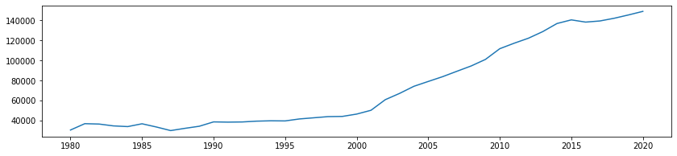

```python
plt.figure(figsize=(14,3)) #How big we want our plot size
plt.plot(mydata7['Year'], mydata7['Gross domestic product, (constant prices US$)'])
plt.show


#Gross domestic product, (constant prices US$) increases over the years and
#has its highest value in year 2020.
```

#### Lets see what we have just done again using **scattered plot**

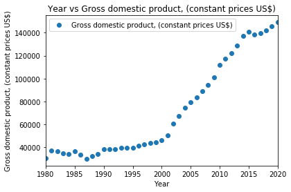

```python
mydata7.plot(x='Year' , y='Gross domestic product, (constant prices US$)' , style='o')
plt.title('Year vs Gross domestic product, (constant prices US$)')
plt.xlabel('Year')
plt.ylabel('Gross domestic product, (constant prices US$)')
plt.show()
```

#### Lets take a look at **Year** against **Household final consumption expenditure (current US$)**

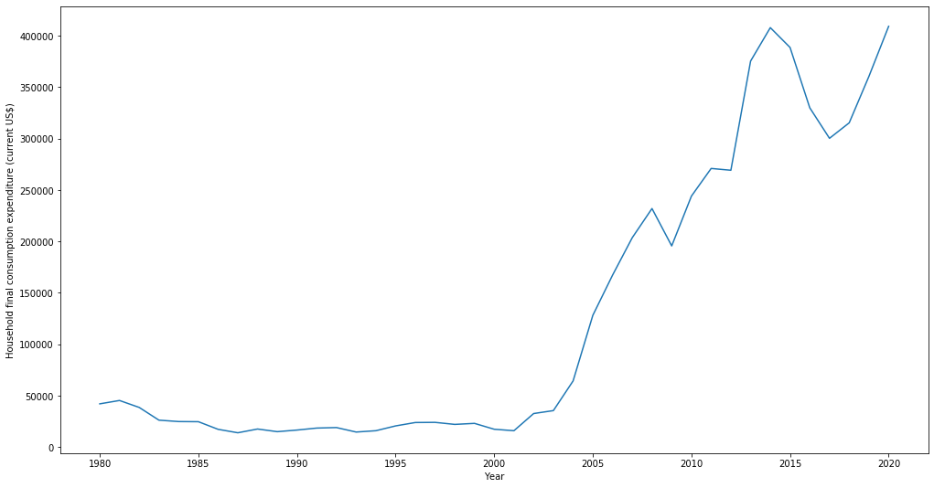

```python
plt.figure(figsize=(17,9))
sns.lineplot(x='Year', y='Household final consumption expenditure (current US$)', data=mydata7)
plt.show()
```

### Lets use subplots for four graphs

**Year** against **Gross domestic product, (constant prices US$)**

**Year** against **Current account balance (Net, BoP, cur. US$)**

**Year** against **Final consumption expenditure (% of GDP)**

**Year** against **Inflation, consumer prices (annual %)**

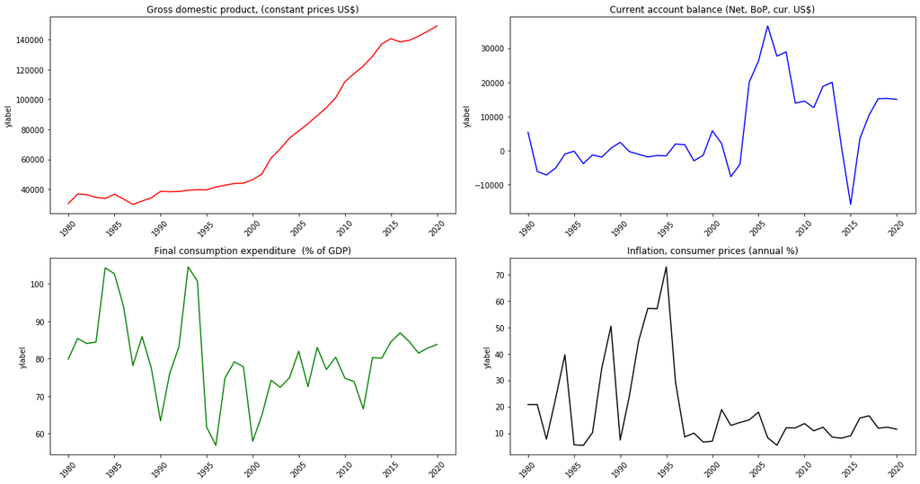

```python
fig, ax=plt.subplots(2,2, figsize=(17,9)) #(2,2) means we want the four graphs arranged in two rows and two columns

ax[0, 0].plot(mydata7['Year'], mydata7['Gross domestic product, (constant prices US$)'], 'r') #r means red color
ax[0, 1].plot(mydata7['Year'], mydata7['Current account balance (Net, BoP, cur. US$)'], 'b') #b means blues color
ax[1, 0].plot(mydata7['Year'], mydata7['Final consumption expenditure  (% of GDP)'], 'g') #g means green color
ax[1, 1].plot(mydata7['Year'], mydata7['Inflation, consumer prices (annual %)'], 'k') #k means black color

ax[0,0].tick_params(axis='x', labelrotation = 45)
ax[0,1].tick_params(axis='x', labelrotation = 45)
ax[1,0].tick_params(axis='x', labelrotation = 45)
ax[1,1].tick_params(axis='x', labelrotation = 45)

ax[0, 0].set_title("Gross domestic product, (constant prices US$)")
ax[1, 0].set_title("Final consumption expenditure  (% of GDP)")
ax[0, 1].set_title("Current account balance (Net, BoP, cur. US$)")
ax[1, 1].set_title("Inflation, consumer prices (annual %)")

ax[0, 0].set_ylabel('ylabel')
ax[0, 1].set_ylabel('ylabel')
ax[1, 0].set_ylabel('ylabel')
ax[1, 1].set_ylabel('ylabel')


fig.tight_layout() #automatically adjusts subplot params so that the subplots fits into the figure area.
plt.show()
```

### Lets plot **Year** against **Gross domestic product, (constant prices US$)** and **Inflation, consumer prices (annual %)** in one graph

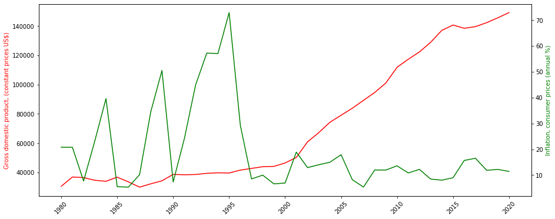

```python
fig, ax1 = plt.subplots(figsize=(15,6))

ax2 = ax1.twinx()
ax1.plot(mydata7['Year'], mydata7['Gross domestic product, (constant prices US$)'], 'r-')
ax2.plot(mydata7['Year'], mydata7['Inflation, consumer prices (annual %)'], 'g-')

ax1.set_ylabel('Gross domestic product, (constant prices US$)', color='r')
ax2.set_ylabel('Inflation, consumer prices (annual %)', color='g')

ax1.tick_params(axis='x', labelrotation = 45)
ax1.tick_params(axis='x', labelrotation = 45)

plt.show()
```

```python
mydata8 = mydata7.copy()
```

### Multiple Linear Regression Correlation Analysis (Using Heat Maps)

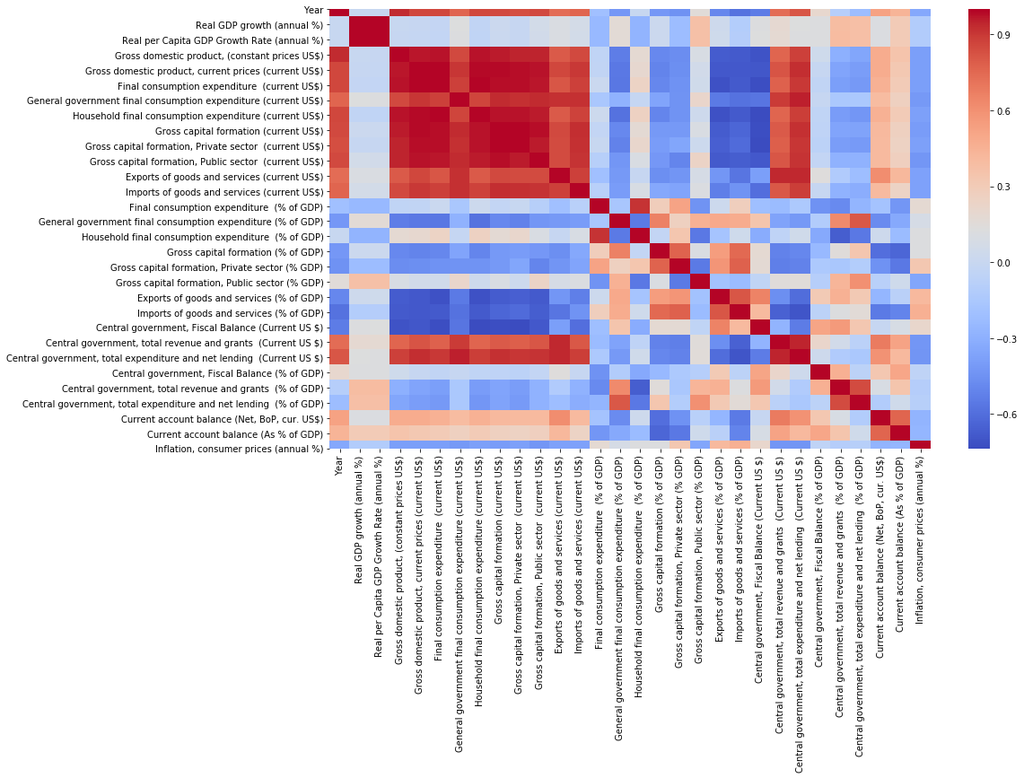

```python
plt.figure(figsize=(15,9))
corr_data = mydata8.corr()
sns.heatmap(corr_data, cmap='coolwarm') #cmap='coolwarm' is just the colour map I want

#negatively correlated is 0.0 downwards and positively corrrelated is 0.0 upward
```

### Lets get a clearer picture of the pairwise correlation of all columns in the dataframe.

```python
mydata8.corr()
```

|  | Year | Real GDP growth (annual %) | Real per Capita GDP Growth Rate (annual %) | Gross domestic product, (constant prices US$) | Gross domestic product, current prices (current US$) | Final consumption expenditure (current US$) | General government final consumption expenditure (current US$) | Household final consumption expenditure (current US$) | Gross capital formation (current US$) | Gross capital formation, Private sector (current US$) | ... | Imports of goods and services (% of GDP) | Central government, Fiscal Balance (Current US $) | Central government, total revenue and grants (Current US $) | Central government, total expenditure and net lending (Current US $) | Central government, Fiscal Balance (% of GDP) | Central government, total revenue and grants (% of GDP) | Central government, total expenditure and net lending (% of GDP) | Current account balance (Net, BoP, cur. US$) | Current account balance (As % of GDP) | Inflation, consumer prices (annual %) |
| --- | --- | --- | --- | --- | --- | --- | --- | --- | --- | --- | --- | --- | --- | --- | --- | --- | --- | --- | --- | --- | --- |
| Year | 1.000000 | -0.001144 | -0.002593 | 0.934378 | 0.863168 | 0.860176 | 0.766080 | 0.859127 | 0.851788 | 0.841072 | ... | -0.581194 | -0.541951 | 0.736978 | 0.810373 | 0.206300 | -0.096570 | -0.224539 | 0.529947 | 0.441672 | -0.342182 |
| Real GDP growth (annual %) | -0.001144 | 1.000000 | 0.999946 | -0.003574 | -0.005283 | -0.022053 | 0.126427 | -0.033908 | 0.019198 | -0.004702 | ... | -0.109875 | 0.121772 | 0.190680 | 0.130653 | 0.120999 | 0.394989 | 0.376294 | 0.117933 | 0.307442 | -0.117683 |
| Real per Capita GDP Growth Rate (annual %) | -0.002593 | 0.999946 | 1.000000 | -0.007678 | -0.010761 | -0.027409 | 0.120590 | -0.039170 | 0.013712 | -0.010287 | ... | -0.104667 | 0.125747 | 0.185378 | 0.124860 | 0.123138 | 0.399037 | 0.379603 | 0.114986 | 0.306447 | -0.114568 |
| Gross domestic product, (constant prices US$) | 0.934378 | -0.003574 | -0.007678 | 1.000000 | 0.969860 | 0.973117 | 0.852312 | 0.973097 | 0.960052 | 0.952050 | ... | -0.681632 | -0.702799 | 0.764486 | 0.882671 | 0.037891 | -0.298473 | -0.349680 | 0.481543 | 0.354511 | -0.386625 |
| Gross domestic product, current prices (current US$) | 0.863168 | -0.005283 | -0.010761 | 0.969860 | 1.000000 | 0.995596 | 0.911833 | 0.992335 | 0.989480 | 0.984587 | ... | -0.684204 | -0.693830 | 0.821627 | 0.927764 | -0.009816 | -0.358724 | -0.394732 | 0.482799 | 0.327255 | -0.390000 |
| Final consumption expenditure (current US$) | 0.860176 | -0.022053 | -0.027409 | 0.973117 | 0.995596 | 1.000000 | 0.884465 | 0.999279 | 0.984982 | 0.980579 | ... | -0.680527 | -0.726045 | 0.782040 | 0.903161 | -0.035687 | -0.387400 | -0.411519 | 0.453146 | 0.306528 | -0.383816 |
| General government final consumption expenditure (current US$) | 0.766080 | 0.126427 | 0.120590 | 0.852312 | 0.911833 | 0.884465 | 1.000000 | 0.866118 | 0.933722 | 0.921713 | ... | -0.585735 | -0.571949 | 0.892110 | 0.956263 | -0.005886 | -0.148567 | -0.149514 | 0.399550 | 0.266539 | -0.414138 |
| Household final consumption expenditure (current US$) | 0.859127 | -0.033908 | -0.039170 | 0.973097 | 0.992335 | 0.999279 | 0.866118 | 1.000000 | 0.979185 | 0.975445 | ... | -0.681352 | -0.731233 | 0.765174 | 0.889702 | -0.037750 | -0.402908 | -0.428667 | 0.452921 | 0.306679 | -0.377466 |
| Gross capital formation (current US$) | 0.851788 | 0.019198 | 0.013712 | 0.960052 | 0.989480 | 0.984982 | 0.933722 | 0.979185 | 1.000000 | 0.995401 | ... | -0.633787 | -0.723001 | 0.802954 | 0.920746 | -0.048567 | -0.358290 | -0.367285 | 0.410488 | 0.261941 | -0.401267 |
| Gross capital formation, Private sector (current US$) | 0.841072 | -0.004702 | -0.010287 | 0.952050 | 0.984587 | 0.980579 | 0.921713 | 0.975445 | 0.995401 | 1.000000 | ... | -0.610126 | -0.736161 | 0.788213 | 0.911293 | -0.059755 | -0.396032 | -0.408916 | 0.407583 | 0.252378 | -0.380729 |
| Gross capital formation, Public sector (current US$) | 0.851239 | 0.061855 | 0.056675 | 0.952083 | 0.975218 | 0.969941 | 0.933594 | 0.963083 | 0.984962 | 0.963880 | ... | -0.661671 | -0.682397 | 0.810803 | 0.916309 | -0.027257 | -0.281862 | -0.283633 | 0.406147 | 0.273077 | -0.428944 |
| Exports of goods and services (current US$) | 0.742050 | 0.110938 | 0.105499 | 0.798280 | 0.863023 | 0.815388 | 0.922450 | 0.798429 | 0.855296 | 0.848943 | ... | -0.568410 | -0.388657 | 0.943890 | 0.940393 | 0.143607 | -0.120902 | -0.218801 | 0.615197 | 0.418363 | -0.373143 |
| Imports of goods and services (current US$) | 0.763380 | 0.066076 | 0.060732 | 0.851965 | 0.901128 | 0.884082 | 0.920224 | 0.872197 | 0.927675 | 0.923175 | ... | -0.443782 | -0.599531 | 0.808174 | 0.885322 | -0.005869 | -0.284164 | -0.315172 | 0.408483 | 0.242845 | -0.373048 |
| Final consumption expenditure (% of GDP) | -0.202104 | -0.244171 | -0.245692 | -0.038215 | -0.033900 | 0.014198 | -0.156516 | 0.027941 | -0.029497 | 0.001763 | ... | 0.274499 | -0.211488 | -0.232629 | -0.140006 | -0.450983 | -0.483848 | -0.269324 | -0.186428 | -0.430053 | 0.181569 |
| General government final consumption expenditure (% of GDP) | -0.423998 | 0.168455 | 0.172000 | -0.535135 | -0.554117 | -0.565161 | -0.286567 | -0.582104 | -0.488909 | -0.517797 | ... | 0.478985 | 0.345573 | -0.369845 | -0.414841 | -0.118359 | 0.631760 | 0.806767 | -0.474693 | -0.334884 | 0.081697 |
| Household final consumption expenditure (% of GDP) | 0.001055 | -0.275842 | -0.278576 | 0.185415 | 0.196805 | 0.242130 | -0.016196 | 0.260693 | 0.173997 | 0.212292 | ... | 0.038012 | -0.320205 | -0.046902 | 0.050039 | -0.334632 | -0.667904 | -0.557051 | 0.034999 | -0.228718 | 0.120865 |
| Gross capital formation (% of GDP) | -0.419239 | 0.017067 | 0.020913 | -0.485362 | -0.506739 | -0.497472 | -0.356439 | -0.503910 | -0.412512 | -0.403644 | ... | 0.753216 | 0.179394 | -0.517648 | -0.496905 | -0.244603 | 0.146411 | 0.336027 | -0.593900 | -0.630232 | 0.123433 |
| Gross capital formation, Private sector (% GDP) | -0.449652 | -0.223384 | -0.221140 | -0.469824 | -0.460402 | -0.446341 | -0.438812 | -0.442438 | -0.412110 | -0.354984 | ... | 0.780640 | 0.174858 | -0.528043 | -0.518444 | -0.145807 | -0.156012 | -0.107271 | -0.446728 | -0.556122 | 0.331033 |
| Gross capital formation, Public sector (% GDP) | 0.152932 | 0.370228 | 0.371754 | 0.098007 | 0.055418 | 0.045618 | 0.218050 | 0.031130 | 0.103240 | 0.025840 | ... | -0.232367 | -0.038105 | 0.146529 | 0.158665 | -0.092295 | 0.434186 | 0.605869 | -0.079697 | 0.043252 | -0.354436 |
| Exports of goods and services (% of GDP) | -0.498180 | 0.035343 | 0.041194 | -0.671473 | -0.688218 | -0.709685 | -0.550496 | -0.715453 | -0.673156 | -0.660158 | ... | 0.815906 | 0.659034 | -0.460292 | -0.600820 | 0.310152 | 0.451152 | 0.319659 | -0.265779 | -0.073041 | 0.412308 |
| Imports of goods and services (% of GDP) | -0.581194 | -0.109875 | -0.104667 | -0.681632 | -0.684204 | -0.680527 | -0.585735 | -0.681352 | -0.633787 | -0.610126 | ... | 1.000000 | 0.407794 | -0.653668 | -0.696268 | -0.058996 | 0.119355 | 0.159506 | -0.552584 | -0.508068 | 0.461545 |
| Central government, Fiscal Balance (Current US $) | -0.541951 | 0.121772 | 0.125747 | -0.702799 | -0.693830 | -0.726045 | -0.571949 | -0.731233 | -0.723001 | -0.736161 | ... | 0.407794 | 1.000000 | -0.276838 | -0.545493 | 0.517776 | 0.560328 | 0.328824 | -0.008907 | 0.084949 | 0.209257 |
| Central government, total revenue and grants (Current US $) | 0.736978 | 0.190680 | 0.185378 | 0.764486 | 0.821627 | 0.782040 | 0.892110 | 0.765174 | 0.802954 | 0.788213 | ... | -0.653668 | -0.276838 | 1.000000 | 0.952308 | 0.214275 | 0.052415 | -0.070935 | 0.687792 | 0.522220 | -0.427652 |
| Central government, total expenditure and net lending (Current US $) | 0.810373 | 0.130653 | 0.124860 | 0.882671 | 0.927764 | 0.903161 | 0.956263 | 0.889702 | 0.920746 | 0.911293 | ... | -0.696268 | -0.545493 | 0.952308 | 1.000000 | 0.033990 | -0.123969 | -0.152636 | 0.593456 | 0.416686 | -0.435193 |
| Central government, Fiscal Balance (% of GDP) | 0.206300 | 0.120999 | 0.123138 | 0.037891 | -0.009816 | -0.035687 | -0.005886 | -0.037750 | -0.048567 | -0.059755 | ... | -0.058996 | 0.517776 | 0.214275 | 0.033990 | 1.000000 | 0.461615 | -0.063401 | 0.329340 | 0.509965 | -0.046874 |
| Central government, total revenue and grants (% of GDP) | -0.096570 | 0.394989 | 0.399037 | -0.298473 | -0.358724 | -0.387400 | -0.148567 | -0.402908 | -0.358290 | -0.396032 | ... | 0.119355 | 0.560328 | 0.052415 | -0.123969 | 0.461615 | 1.000000 | 0.845042 | 0.094945 | 0.346188 | -0.099455 |
| Central government, total expenditure and net lending (% of GDP) | -0.224539 | 0.376294 | 0.379603 | -0.349680 | -0.394732 | -0.411519 | -0.149514 | -0.428667 | -0.367285 | -0.408916 | ... | 0.159506 | 0.328824 | -0.070935 | -0.152636 | -0.063401 | 0.845042 | 1.000000 | -0.114967 | 0.046376 | -0.085551 |
| Current account balance (Net, BoP, cur. US$) | 0.529947 | 0.117933 | 0.114986 | 0.481543 | 0.482799 | 0.453146 | 0.399550 | 0.452921 | 0.410488 | 0.407583 | ... | -0.552584 | -0.008907 | 0.687792 | 0.593456 | 0.329340 | 0.094945 | -0.114967 | 1.000000 | 0.764651 | -0.279179 |
| Current account balance (As % of GDP) | 0.441672 | 0.307442 | 0.306447 | 0.354511 | 0.327255 | 0.306528 | 0.266539 | 0.306679 | 0.261941 | 0.252378 | ... | -0.508068 | 0.084949 | 0.522220 | 0.416686 | 0.509965 | 0.346188 | 0.046376 | 0.764651 | 1.000000 | -0.262080 |
| Inflation, consumer prices (annual %) | -0.342182 | -0.117683 | -0.114568 | -0.386625 | -0.390000 | -0.383816 | -0.414138 | -0.377466 | -0.401267 | -0.380729 | ... | 0.461545 | 0.209257 | -0.427652 | -0.435193 | -0.046874 | -0.099455 | -0.085551 | -0.279179 | -0.262080 | 1.000000 |

30 rows × 30 columns

### Lets do a distance plot of **Inflation, consumer prices (annual %)**

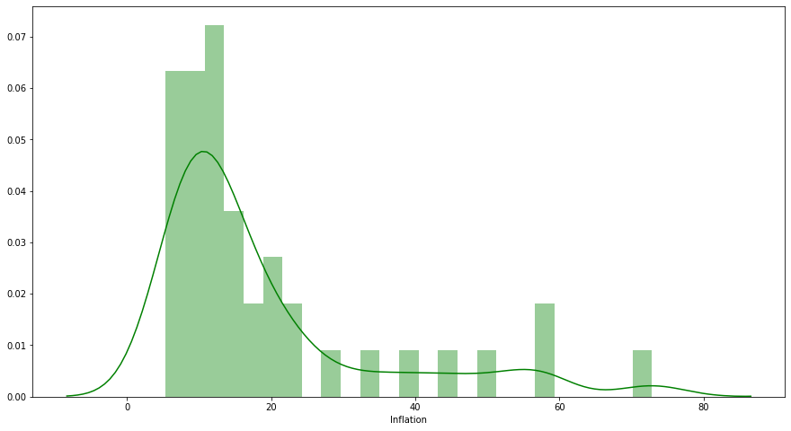

```python
plt.figure(figsize=(15,8))

#Organize Data
inf_dist = pd.Series(mydata8['Inflation, consumer prices (annual %)'], name="Inflation")

#Plot Data
sns.distplot(inf_dist, bins=25, color="g")
plt.show()
```

### Let's Do a Multiple Linear Regression Using **Scikit Learn**

```python
from sklearn import linear_model
import statsmodels.api as sm
#set x to everyother variable except inflation
X = mydata8[['Real GDP growth (annual %)',
       'Real per Capita GDP Growth Rate (annual %)',
       'Gross domestic product, (constant prices US$)',
       'Gross domestic product, current prices (current US$)',
       'Final consumption expenditure  (current US$)',
       'General government final consumption expenditure (current US$)',
       'Household final consumption expenditure (current US$)',
       'Gross capital formation (current US$)',
       'Gross capital formation, Private sector  (current US$)',
       'Gross capital formation, Public sector  (current US$)',
       'Exports of goods and services (current US$)',
       'Imports of goods and services (current US$)',
       'Final consumption expenditure  (% of GDP)',
       'General government final consumption expenditure (% of GDP)',
       'Household final consumption expenditure  (% of GDP)',
       'Gross capital formation (% of GDP)',
       'Gross capital formation, Private sector (% GDP)',
       'Gross capital formation, Public sector (% GDP)',
       'Exports of goods and services (% of GDP)',
       'Imports of goods and services (% of GDP)',
       'Central government, Fiscal Balance (Current US $)',
       'Central government, total revenue and grants  (Current US $)',
       'Central government, total expenditure and net lending  (Current US $)',
       'Central government, Fiscal Balance (% of GDP)',
       'Central government, total revenue and grants  (% of GDP)',
       'Central government, total expenditure and net lending  (% of GDP)',
       'Current account balance (Net, BoP, cur. US$)',
       'Current account balance (As % of GDP)']]
#set y(dependent variable) to inflation
Y = mydata8['Inflation, consumer prices (annual %)']
```

#### scaling or standardization is a step in Data pre processing which is applied to independent variables or feature data. It basically helps to normalize data within a certain range and sometimes helps in speeding up calculations in an algorithm.

```python
from sklearn.preprocessing import StandardScaler
sc_X = StandardScaler()
scaled_X = sc_X.fit_transform(X)
```

```python
scaled_X
```

```
array([[ 2.44371723,  2.42801211, -1.00353287, ...,  0.66462569,
        -0.03025008,  0.98733128],
       [ 2.44371723,  2.42801211, -0.85133019, ...,  0.69852057,
        -1.03594446, -1.16204021],
       [-0.85880323, -0.86445796, -0.86062567, ...,  1.13593209,
        -1.1269956 , -1.55991372],
       ...,
       [-0.40684266, -0.4075612 ,  1.67880516, ..., -0.95177682,
         0.8280262 ,  0.39703327],
       [-0.34689271, -0.34493003,  1.75866711, ..., -0.99974947,
         0.83406815,  0.35294909],
       [-0.33099453, -0.32679201,  1.84407857, ..., -1.03385484,
         0.80961058,  0.30608769]])
```

### Now lets get the equation for the model that is Y= mx + c, where c is the intercept and m is the coefficient of x(gradient)

```python
regr = linear_model.LinearRegression()
regr.fit(scaled_X, Y)

print('Intercept: \n', regr.intercept_)
print('Coefficients: \n', regr.coef_)
```

```
Intercept:
 19.24124972396622
Coefficients:
 [-1.03942632e+03  1.04101850e+03 -1.93986992e+01 -1.59882757e+02
 -3.61313481e+08  2.74363703e+07  3.37290078e+08  2.44452966e+08
 -1.58577946e+08 -8.79265278e+07  2.77443863e+01 -3.28594526e+01
 -1.61588505e+12  7.74965754e+11  1.90362065e+12  1.11402322e+12
 -1.32883275e+12 -8.53133142e+11 -2.07595940e+01  3.46585640e+01
 -4.17066926e+01  1.18981140e+02 -1.07424238e+02  5.14394315e+01
 -1.11557198e+02  9.02159359e+01 -4.20252974e+00  1.34653072e+01]
```

### Now lets predict the **value of Y** (dependent variable that is inflation in this case).

```python
y_pred = regr.predict(scaled_X)
```

### Lets compare the values of y_pred and real y

```python
df = pd.DataFrame({'Actual': Y, 'predicted': y_pred.flatten()})
df
```

|  | Actual | predicted |
| --- | --- | --- |
| 0 | 20.776498 | 5.040523 |
| 1 | 20.776498 | 33.230241 |
| 2 | 7.712262 | 11.206647 |
| 3 | 23.201186 | 10.762026 |
| 4 | 39.601127 | 31.125517 |
| 5 | 5.530642 | 21.148638 |
| 6 | 5.356809 | 16.274509 |
| 7 | 10.187296 | 26.533816 |
| 8 | 34.516158 | 37.368412 |
| 9 | 50.452078 | 38.212039 |
| 10 | 7.357041 | 5.582827 |
| 11 | 24.103010 | 7.257215 |
| 12 | 44.804795 | 28.688923 |
| 13 | 57.169042 | 56.452156 |
| 14 | 57.030042 | 48.824637 |
| 15 | 72.851856 | 53.577613 |
| 16 | 29.261548 | 40.908182 |
| 17 | 8.535616 | 26.297730 |
| 18 | 9.988820 | 12.786265 |
| 19 | 6.617552 | 18.567992 |
| 20 | 6.944444 | 17.536645 |
| 21 | 18.900000 | 13.779686 |
| 22 | 12.900000 | 11.970594 |
| 23 | 14.000000 | 14.215559 |
| 24 | 14.987264 | 16.858147 |
| 25 | 17.900000 | 18.682468 |
| 26 | 8.239527 | 6.772113 |
| 27 | 5.382224 | 8.210180 |
| 28 | 11.980000 | 13.506985 |
| 29 | 11.970000 | 13.704711 |
| 30 | 13.590000 | 19.062722 |
| 31 | 10.840028 | 6.835414 |
| 32 | 12.217782 | 11.214200 |
| 33 | 8.475827 | 5.096721 |
| 34 | 8.062486 | 7.260890 |
| 35 | 9.009387 | 12.501725 |
| 36 | 15.675341 | 10.804152 |
| 37 | 16.523540 | 7.853926 |
| 38 | 11.862134 | 11.110760 |
| 39 | 12.215269 | 14.466172 |
| 40 | 11.434641 | 17.651622 |

### Lets take a look at the mean absolute error of the model

```python
print('Mean Absolute Error:', metrics.mean_absolute_error(Y, y_pred))
```

```
Mean Absolute Error: 6.966935132296664
```

### Lets use the **statsmodel** this time around

```python
import statsmodels.api as sm
X = sm.add_constant(X) # adding a constant

model = sm.OLS(Y, X.values).fit()
predictions = model.predict(X)

print_model = model.summary()
print(print_model)
```

```
                                      OLS Regression Results
=================================================================================================
Dep. Variable:     Inflation, consumer prices (annual %)   R-squared:                       0.599
Model:                                               OLS   Adj. R-squared:                 -0.001
Method:                                    Least Squares   F-statistic:                    0.9978
Date:                                   Sun, 18 Jul 2021   Prob (F-statistic):              0.514
Time:                                           16:52:28   Log-Likelihood:                -153.29
No. Observations:                                     41   AIC:                             356.6
Df Residuals:                                         16   BIC:                             399.4
Df Model:                                             24
Covariance Type:                               nonrobust
==============================================================================
                 coef    std err          t      P>|t|      [0.025      0.975]
------------------------------------------------------------------------------
const        294.8556    324.211      0.909      0.377    -392.440     982.152
x1           -70.0947    114.921     -0.610      0.550    -313.716     173.526
x2            72.6796    118.196      0.615      0.547    -177.884     323.244
x3         -9.062e-06      0.000     -0.018      0.986      -0.001       0.001
x4            -0.0012      0.002     -0.767      0.454      -0.004       0.002
x5             0.0005      0.002      0.329      0.746      -0.003       0.004
x6          8.719e-05      0.002      0.048      0.962      -0.004       0.004
x7             0.0004      0.001      0.488      0.632      -0.001       0.002
x8             0.0027      0.003      1.030      0.318      -0.003       0.008
x9            -0.0006      0.004     -0.168      0.869      -0.008       0.007
x10            0.0032      0.006      0.582      0.569      -0.009       0.015
x11            0.0010      0.002      0.555      0.587      -0.003       0.005
x12           -0.0018      0.001     -1.222      0.239      -0.005       0.001
x13            0.2920      1.117      0.261      0.797      -2.076       2.660
x14            1.1856      1.792      0.662      0.518      -2.613       4.984
x15           -0.8936      0.824     -1.085      0.294      -2.640       0.853
x16           -3.8740      1.496     -2.589      0.020      -7.046      -0.702
x17           -0.2496      1.670     -0.149      0.883      -3.790       3.291
x18           -3.6244      2.492     -1.455      0.165      -8.907       1.658
x19           -1.0858      2.321     -0.468      0.646      -6.006       3.834
x20            2.6412      2.183      1.210      0.244      -1.986       7.268
x21         9.121e-05      0.006      0.016      0.987      -0.012       0.012
x22         7.446e-05      0.006      0.012      0.990      -0.013       0.013
x23            0.0002      0.007      0.029      0.977      -0.014       0.014
x24            3.0964     10.573      0.293      0.773     -19.318      25.511
x25           -4.6472     10.973     -0.424      0.678     -27.909      18.615
x26            3.8161     11.493      0.332      0.744     -20.549      28.181
x27            0.0002      0.001      0.203      0.842      -0.002       0.002
x28            0.2936      2.178      0.135      0.894      -4.324       4.912
==============================================================================
Omnibus:                        3.642   Durbin-Watson:                   1.602
Prob(Omnibus):                  0.162   Jarque-Bera (JB):                3.185
Skew:                           0.096   Prob(JB):                        0.203
Kurtosis:                       4.352   Cond. No.                     2.51e+16
==============================================================================

Warnings:
[1] Standard Errors assume that the covariance matrix of the errors is correctly specified.
[2] The smallest eigenvalue is 1.02e-20. This might indicate that there are
strong multicollinearity problems or that the design matrix is singular.
```

### Lets take a look at the predictions from statsmodel

```python
print(predictions)
```

```
0      6.525841
1     28.287936
2     15.006768
3     12.488454
4     27.724667
5     18.940399
6     20.311360
7     27.043163
8     40.159544
9     31.072122
10    11.330727
11    18.167795
12    25.746824
13    55.515296
14    48.575519
```

[output cut: 27 more lines]

### And this is our Y alone

```python
Y
```

```
0     20.776498
1     20.776498
2      7.712262
3     23.201186
4     39.601127
5      5.530642
6      5.356809
7     10.187296
8     34.516158
9     50.452078
10     7.357041
11    24.103010
12    44.804795
13    57.169042
14    57.030042
```

[output cut: 27 more lines]

### I hope this helps some scientist searching for a python implementation.

```python
import os

os.system('jupyter nbconvert --to html for_medium.ipynb')
```